# Climatic suitability of Australia and New Zealand for the Asian longhorned tick, *Haemaphysalis longicornis*, under current climate

- Show All Code
- Hide All Code
- View Source

A transferable, bias-corrected species distribution model calibrated across the native and invaded ranges

Author

Affiliation

Alexander W. Gofton

CSIRO

Published

October 14, 2026

**Guide to figures and tables**

Figures and tables proposed for the **main text** of a publication are boxed in green and numbered Figure 1, 2, … / Table 1, 2, …. **Supplementary** figures and tables are boxed in grey, numbered Figure S1, S2, … / Table S1, S2, …, and collected in the Supplementary Material section. All code is embedded; click **Show code** to expand any chunk, or use the **Code** menu (top right) to show all code at once.

| Main text | Supplementary |
| --- | --- |
| Figure 1 Occurrence records, accessible area and calibration regions | Figure S1 Predictor collinearity across the accessible area |
| Figure 2 Variable importance and response curves | Figure S2 Target-group sampling-bias surface |
| Figure 3 Current climatic suitability for Australia and New Zealand | Figure S3 Presence vs. background environments by region |
| Figure 4 Niche dynamics between native and invaded ranges | Figure S4 Model tuning across feature classes and regularisation |
| Figure 5 Limiting factors and surveillance gaps | Figure S5 Predicted suitability across the calibration area |
| Table 1 Model evaluation summary | Figure S6 Extrapolation (MESS) and most dissimilar variable |
| Table 2 Suitable area by jurisdiction | Figure S7 Bootstrap uncertainty in predicted suitability |
|  | Figure S8 Niche equivalency and similarity tests |
|  | Figure S9 Sensitivity to background design |
|  | Table S1, Table S2, Table S3, Table S4, Table S5 |

# Abstract

**Aim.** The Asian longhorned tick, *Haemaphysalis longicornis*, is a vector of pathogens of veterinary and public-health importance and has been invasive in Australia and New Zealand for more than a century. We estimated current climatic suitability for the species across both countries using a model selected explicitly for its ability to transfer between regions.

**Location.** Global calibration across the native range (East Asia) and invaded ranges (North America and Oceania); projection to Australia and New Zealand.

**Methods.** We modelled 389 spatially thinned, regionally stratified occurrence records with MaxEnt. To correct for strongly uneven sampling effort, we used a target-group background normalised within each region and allocated among regions in proportion to area. Ten *a priori* predictor sets and their MaxEnt settings were evaluated by leave-one-region-out (LORO) and spatial-block cross-validation, prioritising low omission of withheld records. The selected configurations of the three best-performing predictor sets were combined into a consensus model. We mapped suitability, extrapolation, bootstrap uncertainty, limiting factors and suitable areas far from known records, and compared climatic niches between ranges with ecospat.

**Results.** Only predictor sets containing annual mean temperature transferred reliably between regions. A set derived by automated variance-inflation-factor (VIF) selection, which lacked an absolute temperature variable, ranked sites well within a withheld region but under-predicted suitability there: when Oceania was withheld, it omitted every Oceanian record. The consensus model transferred well (mean LORO AUC = 0.86, continuous Boyce index = 0.81). Trained without any Oceanian records, it predicted the Australian and New Zealand distribution well (AUC = 0.91, Boyce = 0.94). Suitable climate covers about 669,000 km² (8.3% of the two countries): the eastern Australian seaboard from south-east Queensland to Victoria, Tasmania, a small area of south-western Western Australia and almost all of New Zealand. Aridity and large diurnal temperature ranges limit the species inland; high temperatures limit it in the north. About 208,000 km² of suitable climate lies more than 100 km from any known record, mostly in Tasmania, the South Island of New Zealand and western Victoria. The Oceanian niche was equivalent to, and more similar than expected to, the native niche (Schoener’s *D* = 0.47). The recently invaded North American range occupies a small fraction of the native niche (unfilling = 0.96).

**Main conclusions.** The climatic niche of *H. longicornis* has been conserved during invasion of Australia and New Zealand, so native-range information transfers well to these countries, provided models include an absolute temperature gradient and correct for regional sampling imbalance. Climatically suitable but unrecorded areas, particularly Tasmania and southern New Zealand, are priorities for targeted surveillance.

**Keywords:** *Haemaphysalis longicornis*; Asian longhorned tick; species distribution model; MaxEnt; model transferability; niche shift; biosecurity; Australia; New Zealand

**Show code: packages, paths and helpers**

```r
options(java.parameters = "-Xmx12g")   # must be set before rJava starts
suppressPackageStartupMessages({
  library(dismo)          # MaxEnt (maxent.jar) interface; loads raster
  library(terra)
  library(sf)
  library(predicts)       # MESS
  library(ecospat)        # Boyce index, niche overlap / dynamics
  library(ade4)           # PCA for niche analyses
  library(rnaturalearth)
  library(tidyterra)
  library(patchwork)
  library(parallel)
  library(knitr)
  library(tidyverse)      # loaded last so dplyr verbs take precedence
})
sf_use_s2(FALSE)

base_dir <- normalizePath("..")                      # project root (this file lives in code_3/)
proc_v2  <- file.path(base_dir, "processed_data_2")  # upstream inputs (Steps 1-4 of the pipeline)
proc_v3  <- file.path(base_dir, "processed_data_3")  # outputs of this analysis
out_dir  <- file.path(base_dir, "outputs_3")
fig_dir  <- file.path(base_dir, "figures_3")
for (d in c(proc_v3, out_dir, fig_dir)) dir.create(d, showWarnings = FALSE)
terraOptions(memfrac = 0.6, tempdir = file.path(base_dir, "temp"), progress = 0)

theme_set(theme_minimal(base_size = 11) + theme(panel.grid.minor = element_blank()))
regs    <- c("East_Asia", "North_America", "Oceania")
reg_lab <- c(East_Asia = "East Asia (native)", North_America = "North America (invaded)",
             Oceania = "Oceania (invaded)")
reg_col <- c(East_Asia = "#D55E00", North_America = "#0072B2", Oceania = "#009E73")
var_lab <- c(bio1 = "Annual mean temperature (°C)", bio2 = "Mean diurnal range (°C)",
             bio3 = "Isothermality (%)", bio4 = "Temperature seasonality",
             bio5 = "Max temp. warmest month (°C)", bio6 = "Min temp. coldest month (°C)",
             bio7 = "Temperature annual range (°C)", bio10 = "Mean temp. warmest quarter (°C)",
             bio11 = "Mean temp. coldest quarter (°C)", bio12 = "Annual precipitation (mm)",
             bio13 = "Precip. wettest month (mm)", bio14 = "Precip. driest month (mm)",
             bio15 = "Precipitation seasonality (CV)", bio16 = "Precip. wettest quarter (mm)",
             bio17 = "Precip. driest quarter (mm)", pet_idx = "Annual PET (mm)",
             aridity_idx = "Thornthwaite aridity index", cmi_idx = "Climatic moisture index",
             vpd_annual = "Mean annual VPD (hPa)")
save_fig <- function(name, p = last_plot(), w = 8, h = 6)
  ggsave(file.path(fig_dir, paste0(name, ".png")), p, width = w, height = h, dpi = 300, bg = "white")
fmt <- function(x, d = 2) formatC(x, format = "f", digits = d)
fmt_int <- function(x) format(round(x), big.mark = ",")
```

# 1 Introduction

The Asian longhorned tick, *Haemaphysalis longicornis* Neumann, is a three-host ixodid tick native to temperate East Asia: eastern China, the Korean Peninsula, Japan and the Russian Far East (Hoogstraal et al. 1968; Zhao et al. 2020). It parasitises a wide range of mammals and birds and is of considerable veterinary and public-health importance. It transmits *Theileria orientalis*, including the Ikeda genotype responsible for outbreaks of oriental theileriosis in Australian cattle (Kamau et al. 2011), and in East Asia it is a principal vector of severe fever with thrombocytopenia syndrome virus (Yu et al. 2011) and many other pathogens (Zhao et al. 2020). The species exists as bisexual and parthenogenetic populations. Because a single parthenogenetic female can found a population, the parthenogenetic form has spread far beyond the native range (Hoogstraal et al. 1968). It has long been established in eastern Australia, New Zealand and several south-west Pacific islands, where it is an important pest of livestock (Heath 2016). Since its detection in New Jersey in 2017 it has spread rapidly across the eastern United States (Rainey et al. 2018).

Correlative species distribution models (SDMs) are the main tool for estimating where an invasive species could establish, and several have been developed for *H. longicornis*, mostly to forecast its spread in North America (Raghavan et al. 2019; Rochlin 2019; Namgyal et al. 2020). Using such models to predict suitability in an invaded region raises three well-known problems. First, presence-only records reflect sampling effort as much as occurrence, and uncorrected sampling bias distorts both fitted responses and predicted distributions (Phillips et al. 2009). Second, a model is only useful for an invaded region if the species–climate relationship it learns transfers across space. This is not guaranteed when invaded populations occupy climates not used in the native range (niche expansion) or fail to occupy climates used there (unfilling) (Guisan et al. 2014; Petitpierre et al. 2012). Third, complex models and automated variable selection can produce over-fitted response surfaces that interpolate well but extrapolate poorly (Radosavljevic and Anderson 2014; Elith, Kearney, and Phillips 2010; Owens et al. 2013). Despite this, transferability is rarely evaluated directly, and most SDMs are assessed with random or spatial cross-validation within the calibration area (Wenger and Olden 2012; Roberts et al. 2017).

*H. longicornis* is a good case for addressing these issues. It has been recorded across three continents spanning both hemispheres, which allows transfer to be tested explicitly by withholding entire regions. The Australian and New Zealand populations are long-established, and the species’ distribution there is reasonably well documented, which provides a strong test of whether a globally calibrated model reproduces a known invaded range. For Australia and New Zealand, the practical questions are where climate currently permits the tick to persist, which climatic factors limit its spread inland and northward, and which climatically suitable areas lack records and so merit surveillance.

Here we develop a MaxEnt model for *H. longicornis* calibrated across its native and invaded ranges and use it to map current climatic suitability across Australia and New Zealand. Our specific aims were to: (i) correct for strongly uneven sampling effort among regions using a region-balanced target-group background; (ii) select predictors and model complexity explicitly for transferability among regions; (iii) map current suitability, extrapolation risk, uncertainty and limiting climatic factors across Australia and New Zealand; (iv) quantify niche overlap and niche dynamics between the native and invaded ranges; and (v) identify suitable but unrecorded areas as candidate targets for surveillance.

# 2 Methods

## 2.1 Occurrence data

```r
occ <- read_csv(file.path(proc_v2, "occurrences_with_climate.csv"), show_col_types = FALSE) |>
  mutate(region = if_else(region == "Other", "East_Asia", region))   # Himalayan record -> native range

world10 <- ne_countries(scale = 10, returnclass = "sf")
occ_sf  <- st_as_sf(occ, coords = c("lon", "lat"), crs = 4326, remove = FALSE)
occ$country <- world10$admin[st_nearest_feature(occ_sf, world10)]

# All available environmental layers (WorldClim 2.1 bioclim, ENVIREM, CHELSA VPD), 2.5 arcmin
env_all <- rast(file.path(proc_v2, "env_all_global.tif"))
cand_vars <- c(paste0("bio", c(1:7, 10:17)), "pet_idx", "aridity_idx", "cmi_idx", "vpd_annual")
n_occ <- nrow(occ); n_by_reg <- table(occ$region)
```

## 2.2 Environmental predictors

Candidate predictors were the WorldClim 2.1 bioclimatic variables at 2.5 arc-minute resolution (Fick and Hijmans 2017), three ENVIREM moisture variables (annual potential evapotranspiration, Thornthwaite aridity index and climatic moisture index) (Title and Bemmels 2018), and mean annual vapour-pressure deficit (VPD) from CHELSA v2.1 (1981–2010), aggregated from 30 arc-seconds to the WorldClim grid (Karger et al. 2017). BIO8, BIO9, BIO18 and BIO19 were excluded a priori because they combine temperature and precipitation quarters and produce known spatial discontinuities, leaving 19 candidate variables.

## 2.3 Accessible area and background

The accessible area (*M*) (Barve et al. 2011) was defined as the union of 1,000-km buffers around all occurrence records, clipped to land. This encompasses the areas plausibly reachable through livestock movement, wildlife hosts and migratory birds, while excluding the distant and environmentally irrelevant regions that inflate discrimination metrics. *M* was partitioned into the three calibration regions by assigning each grid cell to the region of its nearest occurrence record.

Presence records of *H. longicornis* reflect where people have looked for ticks as much as where the tick occurs. To account for this we used a target-group background (Phillips et al. 2009). Target-group records comprised all georeferenced Ixodidae records on GBIF within *M* plus the tick survey records of Zhang et al. (2019), de-duplicated at 0.1°. Because GBIF tick records are overwhelmingly North American, a single global sampling-effort surface would place almost all background points in North America. We therefore (i) built the sampling-effort surface separately within each region, using a Gaussian kernel (σ = 1°, about 100 km) on 0.25° record counts, normalised to a maximum of 1 within each region with a floor of 0.02 so that unsurveyed areas remain available; and (ii) allocated the 10,000 background points among regions in proportion to each region’s land area within *M*. Within regions, points were drawn with probability proportional to sampling effort × cell area. A second, independent set of 10,000 points was drawn uniformly (area-weighted) across *M* and used only for model evaluation, so that all candidate models were evaluated against a common reference distribution of available environments.

```r
M_r <- rast(file.path(proc_v2, "env_selected_M.tif"))[[1]]
M_r <- classify(!is.na(M_r), cbind(0, NA)); names(M_r) <- "M"

# Region membership of each M cell (nearest occurrence), computed at 0.25 deg then disaggregated
M6  <- aggregate(M_r, 6, fun = "max", na.rm = TRUE)
xy6 <- as.data.frame(M6, xy = TRUE, na.rm = TRUE)[, 1:2]
reg6 <- match(occ$region[st_nearest_feature(st_as_sf(xy6, coords = c("x", "y"), crs = 4326), occ_sf)], regs)
reg_r6 <- rast(M6); reg_r6[cellFromXY(reg_r6, as.matrix(xy6))] <- reg6
reg_r  <- mask(resample(reg_r6, M_r, method = "near"), M_r); names(reg_r) <- "region"

cells  <- which(!is.na(values(reg_r)))
c_reg  <- values(reg_r)[cells]
c_area <- values(cellSize(reg_r, unit = "km"))[cells]
reg_area  <- tapply(c_area, c_reg, sum)
reg_share <- reg_area / sum(reg_area)
n_bg  <- 10000
n_reg <- round(n_bg * reg_share)

# Target-group records (GBIF Ixodidae within M + Zhang et al. 2019 Chinese tick records)
tg_gbif  <- read_csv(file.path(proc_v2, "ixodidae_points.csv"), show_col_types = FALSE)
tg_zhang <- read_csv(file.path(base_dir, "data", "Zhang_et_al_2019_ms_dataset_v1.csv"),
                     show_col_types = FALSE) |> filter(!is.na(lon), !is.na(lat)) |> dplyr::select(lon, lat)
tg <- bind_rows(tg_gbif, tg_zhang) |>
  mutate(lon_b = round(lon, 1), lat_b = round(lat, 1)) |>
  distinct(lon_b, lat_b, .keep_all = TRUE) |> dplyr::select(lon, lat)
tg$region <- occ$region[st_nearest_feature(st_as_sf(tg, coords = c("lon", "lat"), crs = 4326), occ_sf)]

# Region-normalised kernel sampling-effort surface
tg_cnt <- rasterize(as.matrix(tg[, c("lon", "lat")]), M6, fun = "count", background = 0)
tg_kde <- focal(tg_cnt, focalMat(tg_cnt, 1, "Gauss"), fun = "sum", na.rm = TRUE)
tg_kde <- resample(tg_kde, M_r, method = "bilinear")
kv <- values(tg_kde)[cells]; kv[is.na(kv)] <- 0
bias <- numeric(length(cells))
for (r in seq_along(regs)) { i <- c_reg == r; bias[i] <- pmax(kv[i] / max(kv[i]), 0.02) }
bias_r <- rast(reg_r); bias_r[cells] <- bias; names(bias_r) <- "bias"

sample_bg <- function(prob, seed) {
  set.seed(seed)
  idx <- unlist(lapply(seq_along(regs), function(r) {
    i <- which(c_reg == r); sample(i, n_reg[r], prob = prob[i] * c_area[i]) }))
  xy <- xyFromCell(reg_r, cells[idx])
  bind_cols(tibble(lon = xy[, 1], lat = xy[, 2], region = regs[c_reg[idx]]),
            terra::extract(env_all, xy)) |> drop_na(all_of(cand_vars))
}
bg_train   <- sample_bg(bias, 102)                       # bias-corrected training background
bg_uniform <- sample_bg(rep(1, length(cells)), 101)      # uniform background (sensitivity analysis)
bg_eval    <- sample_bg(rep(1, length(cells)), 999)      # independent evaluation background

writeRaster(bias_r, file.path(proc_v3, "bias_surface_regional.tif"), overwrite = TRUE)
write_csv(bg_train, file.path(proc_v3, "background_train.csv"))
write_csv(bg_eval,  file.path(proc_v3, "background_eval.csv"))
```

## 2.4 Variable selection

Collinearity was assessed across the accessible area (on the evaluation background), not at occurrence points, because collinearity among predictors in the environments available to the species is what affects coefficient estimation and transfer (Dormann et al. 2013). Rather than relying on automated stepwise variance-inflation-factor (VIF) elimination, which can discard ecologically critical variables, we defined ten candidate predictor sets *a priori*. Each set contained four or five variables spanning the axes known to constrain the off-host survival and development of ixodid ticks: thermal regime or thermal limits, temperature variability, moisture supply, and desiccation stress (Needham and Teel 1991; Heath 2016). All sets satisfied |Spearman’s ρ| ≤ 0.75 and VIF < 5 across *M* (Table S2). Set A reproduces the predictors selected by stepwise VIF reduction in an earlier iteration of this analysis and contains no absolute temperature variable. Each candidate set was evaluated over a grid of MaxEnt settings (see below) and the set containing the best-ranked configurations were carried forward (see below).

```r
cand_sets <- list(
  A = c("bio2", "bio3", "bio13", "aridity_idx", "vpd_annual"),
  B = c("bio5", "bio6", "bio13", "bio17", "aridity_idx"),
  C = c("bio1", "bio2", "bio12", "bio15", "aridity_idx"),
  D = c("bio2", "bio5", "bio6", "bio13", "aridity_idx"),
  E = c("vpd_annual", "bio4", "bio13", "bio17", "aridity_idx"),
  F = c("bio5", "bio6", "bio12", "bio15", "aridity_idx"),
  G = c("bio1", "bio2", "bio13", "bio17", "aridity_idx"),
  H = c("bio1", "bio12", "bio15", "aridity_idx"),
  I = c("bio10", "bio2", "bio12", "bio15", "aridity_idx"),
  J = c("bio11", "bio2", "bio12", "bio15", "aridity_idx"))
set_desc <- c(A = "Stepwise-VIF set (no absolute temperature)", B = "Thermal extremes + seasonal moisture",
              C = "Mean temperature + annual moisture", D = "Thermal extremes + diurnal range",
              E = "Evaporative demand (VPD)", F = "Thermal extremes + annual moisture",
              G = "Mean temperature + seasonal moisture extremes", H = "Minimal (no diurnal range)",
              I = "Summer temperature", J = "Winter temperature")
cor_bg <- cor(bg_eval[, cand_vars], method = "spearman")
set_coll <- imap_dfr(cand_sets, function(v, nm) {
  cm <- abs(cor_bg[v, v]); diag(cm) <- 0
  tibble(set = nm, description = set_desc[nm], variables = paste(v, collapse = ", "),
         max_abs_rho = max(cm), max_VIF = max(usdm::vif(as.data.frame(bg_eval[, v]))$VIF))
})
```

## 2.5 Model calibration, evaluation and selection

Models were fitted with MaxEnt 3.4 (Phillips, Anderson, and Schapire 2006; Phillips et al. 2017) through `dismo`, with clamping enabled, threshold features disabled and complementary log-log (cloglog) output. Because the aim is to predict suitability in a region where the species is invasive, models were evaluated primarily on **transferability** (Wenger and Olden 2012; Roberts et al. 2017), using two spatially structured cross-validation schemes:

1. **Leave-one-region-out (LORO):** models were trained on two regions and tested on the third (East Asia, North America, Oceania). This is the most direct test of the task of interest, predicting suitability in a region from which no records were used.
2. **Spatial block cross-validation:** 5° × 5° blocks were randomly assigned to five folds, so training and test data were spatially separated within regions.

In each fold, training background points falling in the test region or blocks were withheld. Test presences were contrasted with evaluation-background points from the same test region or blocks. Discrimination within the test area was measured by the area under the ROC curve (AUC). Calibration of the predicted presence/expected ratio was measured by the continuous Boyce index (CBI) (Hirzel et al. 2006). Over-fitting and transfer failure were measured by the omission rate of test presences at the 10th-percentile training-presence threshold (OR10; expected value 0.10) (Radosavljevic and Anderson 2014). Configurations were selected with sequential criteria that prioritise omission, following Radosavljevic and Anderson (2014) and Kass et al. (2021). First, we retained configurations with mean LORO OR10 ≤ 0.30 and mean block OR10 ≤ 0.20. These bounds allow transferred models up to three times, and within-region models up to twice, the expected omission of 0.10. Discrimination metrics alone can be misleading under transfer: a model can rank sites correctly within a withheld region (high AUC) while predicting uniformly low suitability there, and so omit almost all records at any threshold calibrated on the training data. Second, the retained configurations were ranked on mean AUC and CBI under each scheme, and the configuration with the lowest rank sum was selected. The three top-ranked predictor sets were carried forward. For each, feature classes (L, LQ, LQH, LQHP) and regularisation multipliers (β = 0.5–8) were tuned over the full grid with the same criteria (Kass et al. 2021). The top-ranked sets differed by small margins relative to the variation among folds, so rather than relying on a single predictor set we combined the selected configuration of each set into an unweighted consensus model (mean cloglog suitability of the three members). This propagates uncertainty in predictor choice into the predictions. The consensus was evaluated with exactly the same cross-validation folds, refitting all three members within each fold.

**Show code: model fitting and cross-validation functions**

```r
fc_args <- function(fc) {
  f <- strsplit(fc, "")[[1]]
  c(paste0("linear=", "L" %in% f), paste0("quadratic=", "Q" %in% f), paste0("hinge=", "H" %in% f),
    paste0("product=", "P" %in% f), "threshold=false", "autofeature=false")
}
fit_mx <- function(p, a, vars, fc, rm) {
  x <- rbind(as.data.frame(p[, vars]), as.data.frame(a[, vars]))
  dismo::maxent(x = x, p = c(rep(1, nrow(p)), rep(0, nrow(a))),
                args = c(fc_args(fc), paste0("betamultiplier=", rm), "doclamp=true"))
}
pred_mx <- function(m, x, vars)
  as.numeric(dismo::predict(m, as.data.frame(x[, vars]), args = "outputformat=cloglog"))
auc_fun <- function(pp, pa) {             # Mann-Whitney AUC
  r <- rank(c(pp, pa)); np <- length(pp)
  (sum(r[seq_len(np)]) - np * (np + 1) / 2) / (np * length(pa)) }
cbi_fun <- function(pp, pa)
  tryCatch(ecospat.boyce(fit = c(pa, pp), obs = pp, nclass = 0, PEplot = FALSE)$cor, error = function(e) NA)

# Spatial blocks: 5-degree cells randomly allocated to 5 folds
blk_id <- function(lon, lat) paste(floor(lon / 5), floor(lat / 5))
set.seed(2024)
all_blk  <- unique(blk_id(c(occ$lon, bg_train$lon, bg_eval$lon, bg_uniform$lon),
                          c(occ$lat, bg_train$lat, bg_eval$lat, bg_uniform$lat)))
blk_fold <- setNames(sample(rep(1:5, length.out = length(all_blk))), all_blk)
add_block <- function(x) mutate(x, block = unname(blk_fold[blk_id(lon, lat)]))
occ <- add_block(occ); bg_train <- add_block(bg_train); bg_eval <- add_block(bg_eval)
bg_uniform <- add_block(bg_uniform)

run_cv <- function(vars, fc, rm, bg, scheme) {
  folds <- if (scheme == "loro") regs else 1:5
  ko <- if (scheme == "loro") occ$region else occ$block
  kb <- if (scheme == "loro") bg$region else bg$block
  ke <- if (scheme == "loro") bg_eval$region else bg_eval$block
  map_dfr(folds, function(k) {
    tr <- occ[ko != k, ]; te <- occ[ko == k, ]
    m  <- fit_mx(tr, bg[kb != k, ], vars, fc, rm)
    pp <- pred_mx(m, te, vars); pe <- pred_mx(m, bg_eval[ke == k, ], vars)
    thr <- quantile(pred_mx(m, tr, vars), 0.10)
    tibble(scheme = scheme, fold = as.character(k), n_test = nrow(te),
           auc = auc_fun(pp, pe), cbi = cbi_fun(pp, pe), or10 = mean(pp < thr))
  })
}
cv_summary <- function(cv) {
  l <- filter(cv, scheme == "loro"); b <- filter(cv, scheme == "block")
  tibble(loro_auc = mean(l$auc), loro_cbi = mean(l$cbi, na.rm = TRUE), loro_or10 = mean(l$or10),
         blk_auc = mean(b$auc), blk_cbi = mean(b$cbi, na.rm = TRUE), blk_or10 = mean(b$or10))
}
# Sequential selection: omission filter first, then rank sum of discrimination / calibration metrics
select_config <- function(d, max_or_loro = 0.30, max_or_blk = 0.20) {
  pass <- filter(d, loro_or10 <= max_or_loro, blk_or10 <= max_or_blk)
  if (nrow(pass) == 0) pass <- slice_min(d, loro_or10, n = 1)    # fallback: lowest transfer omission
  pass |> mutate(rank_sum = rank(-loro_auc) + rank(-loro_cbi) + rank(-blk_auc) + rank(-blk_cbi)) |>
    arrange(rank_sum)
}
# Consensus helpers: members = list of list(set, vars, fc, rm)
fit_ens  <- function(p, a, members) lapply(members, function(cf) fit_mx(p, a, cf$vars, cf$fc, cf$rm))
ens_pred_df <- function(ms, x) rowMeans(sapply(seq_along(ms), function(i) pred_mx(ms[[i]], x, members[[i]]$vars)))
ens_pred_rast <- function(ms, r) mean(rast(lapply(seq_along(ms), function(i)
  predict(r[[members[[i]]$vars]], ms[[i]], args = "outputformat=cloglog", na.rm = TRUE))))
run_cv_ens <- function(bg, scheme) {
  folds <- if (scheme == "loro") regs else 1:5
  ko <- if (scheme == "loro") occ$region else occ$block
  kb <- if (scheme == "loro") bg$region else bg$block
  ke <- if (scheme == "loro") bg_eval$region else bg_eval$block
  map_dfr(folds, function(k) {
    tr <- occ[ko != k, ]; te <- occ[ko == k, ]
    ms <- fit_ens(tr, bg[kb != k, ], members)
    pp <- ens_pred_df(ms, te); pe <- ens_pred_df(ms, bg_eval[ke == k, ])
    thr <- quantile(ens_pred_df(ms, tr), 0.10)
    tibble(scheme = scheme, fold = as.character(k), n_test = nrow(te),
           auc = auc_fun(pp, pe), cbi = cbi_fun(pp, pe), or10 = mean(pp < thr))
  })
}
run_grid <- function(grid, bg) {
  cl <- makeCluster(min(7, detectCores() - 1))
  on.exit(stopCluster(cl))
  clusterEvalQ(cl, { options(java.parameters = "-Xmx1g")
    suppressPackageStartupMessages({ library(dismo); library(ecospat); library(dplyr); library(purrr); library(tibble) })
    NULL })
  clusterExport(cl, c("fc_args", "fit_mx", "pred_mx", "auc_fun", "cbi_fun", "run_cv", "cv_summary",
                      "occ", "bg_eval", "regs", "grid", "bg"), envir = environment())
  bind_rows(parLapplyLB(cl, seq_len(nrow(grid)), function(i) {
    g <- grid[i, ]; v <- g$vars[[1]]
    cv <- bind_rows(run_cv(v, g$fc, g$rm, bg, "loro"), run_cv(v, g$fc, g$rm, bg, "block"))
    bind_cols(dplyr::select(g, -vars), cv_summary(cv))
  }))
}
```

```r
# Stage 1: compare candidate variable sets across a reduced tuning grid
grid_sets <- expand_grid(set = names(cand_sets), fc = c("LQ", "LQH", "LQHP"), rm = c(1, 2, 4, 8)) |>
  mutate(vars = cand_sets[set])
set_res <- run_grid(grid_sets, bg_train) |> mutate(pass = loro_or10 <= 0.30 & blk_or10 <= 0.20)
ranked_sets <- select_config(set_res)
sel_sets <- head(unique(ranked_sets$set), 3)     # three top-ranked predictor sets
# Best configuration per set: best-ranked passing configuration, or (if none pass) lowest transfer omission
best_by_set <- bind_rows(
  ranked_sets |> group_by(set) |> slice_min(rank_sum, n = 1, with_ties = FALSE),
  set_res |> filter(!set %in% ranked_sets$set) |> group_by(set) |> slice_min(loro_or10, n = 1, with_ties = FALSE)) |>
  ungroup() |> arrange(!pass, rank_sum, loro_or10)
# Per-region transfer of the temperature-free set A in its best-discriminating configuration
a_best <- set_res |> filter(set == "A") |>
  mutate(r = rank(-loro_auc) + rank(-loro_cbi) + rank(-blk_auc) + rank(-blk_cbi)) |> slice_min(r, n = 1, with_ties = FALSE)
cv_A <- run_cv(cand_sets$A, a_best$fc, a_best$rm, bg_train, "loro")
write_csv(set_res, file.path(out_dir, "candidate_set_cv_grid.csv"))
```

```r
# Stage 2: full tuning grid for each of the three top-ranked predictor sets
grid_tune <- expand_grid(set = sel_sets, fc = c("L", "LQ", "LQH", "LQHP"), rm = c(0.5, 1, 2, 3, 4, 6, 8)) |>
  mutate(vars = cand_sets[set])
tune_all <- run_grid(grid_tune, bg_train)
tune_sel <- map_dfr(sel_sets, ~ select_config(filter(tune_all, set == .x)) |> slice(1))
members  <- pmap(tune_sel |> dplyr::select(set, fc, rm), function(set, fc, rm)
  list(set = set, vars = cand_sets[[set]], fc = fc, rm = rm))
names(members) <- sel_sets
sel_vars <- unique(unlist(map(members, "vars")))          # union of predictors used by the consensus
sel_vars <- cand_vars[cand_vars %in% sel_vars]
write_csv(tune_all, file.path(out_dir, "tuning_cv_grid.csv"))
```

Each consensus member was refitted to all records. Variable importance was summarised as MaxEnt permutation importance of each member (Phillips et al. 2017). Marginal response curves of the consensus were computed with the other predictors held at their median value across presence records. Uncertainty was quantified by refitting the model to 30 bootstrap resamples of the presence records (resampling within regions to preserve regional composition; all three members were refitted to each resample). We report the across-replicate 95% interval for response curves and the across-replicate standard deviation for mapped suitability.

```r
m_final <- fit_ens(occ, bg_train, members)          # list of the three member models
saveRDS(list(members = members, models = m_final), file.path(proc_v3, "final_consensus_models.rds"))

var_imp <- imap_dfr(m_final, function(m, nm) {
  v <- members[[nm]]$vars; r <- m@results
  tibble(set = nm, variable = v, contribution = r[paste0(v, ".contribution"), 1],
         permutation = r[paste0(v, ".permutation.importance"), 1]) })
imp_order <- var_imp |> group_by(variable) |> summarise(mean_perm = sum(permutation) / length(members)) |>
  arrange(desc(mean_perm))
n_feat <- map_int(m_final, function(m) {
  lam <- m@lambdas; lam <- lam[!grepl("^(linearPredictorNormalizer|densityNormalizer|numBackgroundPoints|entropy)", lam)]
  sum(as.numeric(sapply(strsplit(lam, ","), `[`, 2)) != 0) })

# Consensus cross-validation by fold (all members refitted within each fold)
cv_final <- bind_rows(run_cv_ens(bg_train, "loro"), run_cv_ens(bg_train, "block"))
cvs_final <- cv_summary(cv_final)
write_csv(cv_final, file.path(out_dir, "final_model_cv_folds.csv"))

# Thresholds and in-sample discrimination
p_occ  <- ens_pred_df(m_final, occ)
p_eval <- ens_pred_df(m_final, bg_eval)
thr_p10 <- unname(quantile(p_occ, 0.10))
ev <- dismo::evaluate(p = p_occ, a = p_eval)
thr_mss <- ev@t[which.max(ev@TPR + ev@TNR)]
insample <- tibble(region = regs) |>
  mutate(auc = map_dbl(region, ~ auc_fun(p_occ[occ$region == .x], p_eval[bg_eval$region == .x])),
         cbi = map_dbl(region, ~ cbi_fun(p_occ[occ$region == .x], p_eval[bg_eval$region == .x])),
         pct_suitable = map_dbl(region, ~ 100 * mean(p_occ[occ$region == .x] >= thr_p10)))
auc_all <- auc_fun(p_occ, p_eval); cbi_all <- cbi_fun(p_occ, p_eval)
```

```r
n_boot <- 30
set.seed(31)
boot_models <- map(seq_len(n_boot), function(b) {
  idx <- unlist(lapply(regs, function(r) { i <- which(occ$region == r); i[sample.int(length(i), replace = TRUE)] }))
  fit_ens(occ[idx, ], bg_train, members)
})
```

## 2.6 Projection to Australia and New Zealand

The consensus model was projected onto Australia and New Zealand (110–180°E, 8–48°S, restricted to the land area of the two countries). Climatic suitability was converted to suitable/unsuitable using the 10th-percentile training-presence threshold. This threshold is appropriate for presence-background data and tolerates a small proportion of erroneous or sink-population records (Liu, White, and Newell 2013); the threshold maximising sensitivity + specificity against the evaluation background is reported for comparison. Extrapolation was assessed with the multivariate environmental similarity surface (MESS) and the most dissimilar variable (Elith, Kearney, and Phillips 2010), using presence and training-background environments as the reference. To identify the climatic factor constraining suitability in each grid cell, we computed limiting factors following Elith, Kearney, and Phillips (2010): for each predictor in turn, its value was set to the median across presence records and the predictor yielding the largest increase in suitability was taken as limiting.

To identify candidate areas for surveillance, suitable cells were classified by their geodesic distance to the nearest known Oceanian record (training records plus all georeferenced ALA records). Suitable cells more than 100 km from any known record were designated as *suitable but unrecorded*. Areas were computed from true (latitude-dependent) cell areas and summarised by Australian state/territory and New Zealand island.

```r
aunz_poly <- world10 |> filter(admin %in% c("Australia", "New Zealand")) |> st_union() |> vect()
env_au <- crop(env_all[[sel_vars]], ext(110, 180, -48, -8)) |> mask(aunz_poly)
pred_cur <- ens_pred_rast(m_final, env_au)
names(pred_cur) <- "suitability"
writeRaster(pred_cur, file.path(proc_v3, "suitability_current_aunz.tif"), overwrite = TRUE)

# Bootstrap prediction uncertainty
boot_stack <- rast(lapply(boot_models, ens_pred_rast, r = env_au))
boot_sd   <- app(boot_stack, sd)
boot_bin  <- app(boot_stack >= thr_p10, mean)          # proportion of replicates predicting suitable
names(boot_sd) <- "sd"; names(boot_bin) <- "agreement"
writeRaster(boot_sd, file.path(proc_v3, "suitability_bootstrap_sd_aunz.tif"), overwrite = TRUE)

# Extrapolation (MESS) relative to calibration environments
ref_env <- bind_rows(occ[, sel_vars], bg_train[, sel_vars])
mess_full <- predicts::mess(env_au, as.data.frame(ref_env), full = TRUE)
mess_r <- mess_full[["mess"]]
mod_r  <- which.min(mess_full[[paste0(sel_vars, "_mess")]]); mod_r <- mask(mod_r, mess_r < 0, maskvalues = 0)
writeRaster(mess_r, file.path(proc_v3, "mess_current_aunz.tif"), overwrite = TRUE)

# Limiting factors (Elith et al. 2010)
gain <- rast(lapply(sel_vars, function(v) {
  e2 <- env_au; e2[[v]] <- mask(init(e2[[v]], median(occ[[v]])), e2[[v]])
  ens_pred_rast(m_final, e2) - pred_cur }))
names(gain) <- sel_vars
limit_r <- which.max(gain)

# Binary suitability and surveillance gaps
suit_bin <- pred_cur >= thr_p10
ala <- read_csv(file.path(base_dir, "data", "ALA_occurence", "records-2026-02-04.csv"),
                show_col_types = FALSE) |>
  transmute(lon = decimalLongitude, lat = decimalLatitude) |> drop_na()
known <- bind_rows(occ |> filter(region == "Oceania") |> dplyr::select(lon, lat), ala) |> distinct()
dist_known <- distance(pred_cur, vect(known, geom = c("lon", "lat"), crs = "EPSG:4326")) / 1000
dist_known <- mask(dist_known, pred_cur)
gap_r <- ifel(suit_bin == 0, 0, ifel(dist_known <= 100, 1, 2))   # 0 unsuitable, 1 suitable near records, 2 gap

# Jurisdictions (Australian states/territories; NZ islands)
jur <- ne_states(country = c("Australia", "New Zealand"), returnclass = "sf") |>
  mutate(jur = case_when(admin == "Australia" & name %in% c("Jervis Bay Territory", "Lord Howe Island", "Macquarie Island") ~ "Other territories",
                         admin == "Australia" ~ name,
                         region == "North Island" ~ "NZ North Island",
                         region == "South Island" ~ "NZ South Island",
                         TRUE ~ "NZ outlying islands")) |>
  group_by(jur) |> summarise(geometry = st_union(geometry), .groups = "drop")
jur_r  <- rasterize(vect(jur), pred_cur, field = "jur")
carea  <- cellSize(pred_cur, unit = "km") |> mask(pred_cur)
zone_area <- function(x) { z <- zonal(carea * x, jur_r, fun = "sum", na.rm = TRUE); setNames(z[[2]], z[[1]]) }
area_tab <- tibble(jurisdiction = levels(jur_r)[[1]]$jur) |>
  mutate(land_km2     = zone_area(carea > 0)[jurisdiction],
         suitable_km2 = zone_area(suit_bin)[jurisdiction],
         suitable_analog_km2 = zone_area(suit_bin * (mess_r >= 0))[jurisdiction],
         gap_km2      = zone_area(gap_r == 2)[jurisdiction]) |>
  filter(land_km2 > 1000) |>
  mutate(pct_suitable = 100 * suitable_km2 / land_km2) |> arrange(desc(suitable_km2))
write_csv(area_tab, file.path(out_dir, "suitable_area_by_jurisdiction.csv"))
tot <- global(c(carea, carea * suit_bin, carea * (mess_r < 0), carea * (gap_r == 2)), "sum", na.rm = TRUE)[[1]]
names(tot) <- c("land", "suitable", "novel", "gap")
```

## 2.7 Niche comparison between native and invaded ranges

To understand why transfer between regions succeeds or fails, we compared the realised climatic niche of the native range (East Asia) with each invaded range in a common environmental space (Broennimann et al. 2012; Di Cola et al. 2017). A principal component analysis (PCA) of the selected predictors was calibrated on the evaluation background across all three regions. Occurrence and background densities were estimated on a 100 × 100 grid of the first two axes. We calculated Schoener’s *D*, niche equivalency and similarity tests (100 randomisations; similarity with the native niche held fixed) (Warren, Glor, and Turelli 2008), and the niche dynamics indices of stability, expansion and unfilling calculated in climates shared by both ranges (intersection = 0.1) (Guisan et al. 2014).

```r
pca <- dudi.pca(bg_eval[, sel_vars], scannf = FALSE, nf = 2)
sc_bg  <- pca$li
sc_occ <- suprow(pca, occ[, sel_vars])$li
grid_z <- function(r) ecospat.grid.clim.dyn(glob = sc_bg, glob1 = sc_bg[bg_eval$region == r, ],
                                          sp = sc_occ[occ$region == r, ], R = 100, th.sp = 0, th.env = 0)
z <- setNames(lapply(regs, grid_z), regs)
niche_cmp <- function(nat, inv) {
  set.seed(7)
  eq  <- ecospat.niche.equivalency.test(z[[nat]], z[[inv]], rep = 100, overlap.alternative = "lower", ncores = 1)
  sim <- ecospat.niche.similarity.test(z[[nat]], z[[inv]], rep = 100, rand.type = 2, ncores = 1)
  dyn <- ecospat.niche.dyn.index(z[[nat]], z[[inv]], intersection = 0.1)$dynamic.index.w
  list(eq = eq, sim = sim,
       tab = tibble(comparison = paste(reg_lab[nat], "vs", reg_lab[inv]),
                    D = ecospat.niche.overlap(z[[nat]], z[[inv]], cor = TRUE)$D,
                    p_equivalency = eq$p.D, p_similarity = sim$p.D,
                    stability = dyn[["stability"]], expansion = dyn[["expansion"]], unfilling = dyn[["unfilling"]]))
}
nc_oc <- niche_cmp("East_Asia", "Oceania")
nc_na <- niche_cmp("East_Asia", "North_America")
niche_tab <- bind_rows(nc_oc$tab, nc_na$tab)
write_csv(niche_tab, file.path(out_dir, "niche_comparison.csv"))
```

## 2.8 Sensitivity analysis

To test whether conclusions depended on the sampling-bias correction, the consensus members were refitted with a background drawn uniformly across *M* (same regional allocation, no target-group weighting), and its cross-validated performance and Australian/New Zealand predictions were compared with those of the final model.

```r
m_unif <- fit_ens(occ, bg_uniform, members)
cv_unif <- bind_rows(run_cv_ens(bg_uniform, "loro"), run_cv_ens(bg_uniform, "block"))
pred_unif <- ens_pred_rast(m_unif, env_au)
thr_unif  <- quantile(ens_pred_df(m_unif, occ), 0.10)
sens_vals <- na.omit(cbind(values(pred_cur), values(pred_unif)))
sens_cor  <- cor(sens_vals[, 1], sens_vals[, 2], method = "spearman")
bin_agree <- mean((sens_vals[, 1] >= thr_p10) == (sens_vals[, 2] >= thr_unif))
```

All analyses were run in R 4.4.1 using `terra`, `sf`, `dismo` 1.3.16 (bundled MaxEnt 3.4 Java executable), `predicts`, `ecospat` and the `tidyverse`.

# 3 Results

## 3.1 Occurrence data and calibration environments

The final dataset comprised 389 thinned records: 215 from the native East Asian range, 53 from North America and 121 from Oceania (Figure 1; Table S1). The accessible area covered 22 million km² of land, of which East Asia, North America and Oceania made up 52%, 27% and 21%, respectively. The 12,921 de-duplicated target-group tick records were strongly concentrated in North America (80%), confirming the need for region-specific normalisation of the sampling-effort surface (Figure S2). Presence records occupied a subset of the available environments in each region, generally the warmer, wetter and less arid portion of *M* (Figure S3).

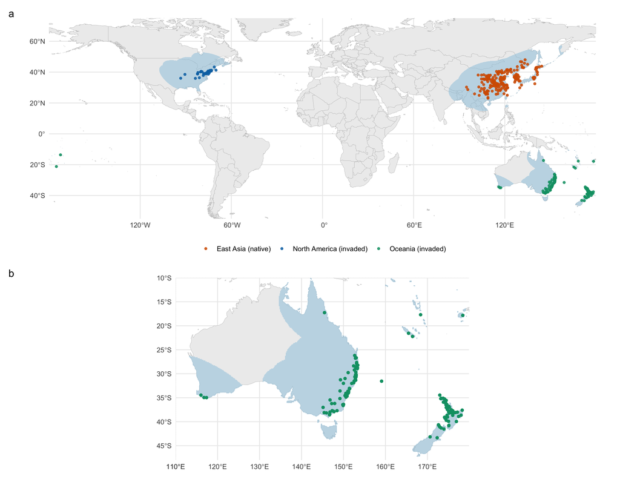

Figure 1: Occurrence records of *Haemaphysalis longicornis* used for model calibration (n = 389 after 10-km thinning and regional stratification), coloured by calibration region. Shading shows the accessible area (*M*; union of 1,000-km buffers around records, clipped to land). (a) Global view; (b) Australia, New Zealand and the south-west Pacific.

```r
world50 <- ne_countries(scale = 50, returnclass = "sf")
M_df <- as.data.frame(aggregate(M_r, 4, fun = "max", na.rm = TRUE), xy = TRUE, na.rm = TRUE)
p_glob <- ggplot() +
  geom_sf(data = world50, fill = "grey93", colour = "grey75", linewidth = 0.15) +
  geom_tile(data = M_df, aes(x, y), fill = "#9ecae1", alpha = 0.55) +
  geom_point(data = occ, aes(lon, lat, colour = region), size = 1.1, alpha = 0.85) +
  scale_colour_manual(values = reg_col, labels = reg_lab, name = NULL) +
  coord_sf(xlim = c(-180, 180), ylim = c(-55, 75), expand = FALSE) +
  labs(x = NULL, y = NULL, tag = "a") + theme(legend.position = "bottom")
p_oce <- ggplot() +
  geom_sf(data = world50, fill = "grey93", colour = "grey75", linewidth = 0.15) +
  geom_tile(data = filter(M_df, x > 105, y < -5), aes(x, y), fill = "#9ecae1", alpha = 0.55) +
  geom_point(data = filter(occ, region == "Oceania"), aes(lon, lat), colour = reg_col["Oceania"], size = 1.4) +
  coord_sf(xlim = c(110, 180), ylim = c(-48, -10), expand = FALSE) +
  labs(x = NULL, y = NULL, tag = "b")
p_fig1 <- p_glob / p_oce + plot_layout(heights = c(1.1, 1))
p_fig1
save_fig("Fig1_occurrences_M", p_fig1, 11, 8.5)
```

## 3.2 Variable selection and model tuning

Of the 120 set × configuration combinations, 36 passed the omission filter, all of them from sets C, G, H, I (Table S2). Every one of these sets includes a direct temperature variable. The temperature-free set A had no passing configuration. In its best-discriminating configuration (LQ, β = 1), set A ranked sites well within the withheld regions (mean LORO AUC = 0.85) but failed to transfer suitability levels: when Oceania was withheld, 100% of Oceanian records fell below the training threshold (East Asia: 42%). The three top-ranked sets were H, C, G. All of them combine annual mean temperature with moisture-supply and aridity variables, and they differed only marginally in performance (Table S2). After tuning, the consensus members were set H (bio1, bio12, bio15, aridity_idx; LQ, β = 3; 6 features); set C (bio1, bio2, bio12, bio15, aridity_idx; LQ, β = 2; 8 features); set G (bio1, bio2, bio13, bio17, aridity_idx; LQH, β = 4; 29 features). Simple, regularised configurations transferred best in all three sets (Figure S4).

## 3.3 Model performance

The consensus model discriminated presences from available environments in every withheld region (Table 1; Table S3). Transfer to Oceania from the native and North American records alone was strong (AUC = 0.91, CBI = 0.94), indicating that the climatic conditions occupied in Australia and New Zealand are predictable from the rest of the range. Transfer to East Asia was the weakest (AUC = 0.74) and had the highest omission (OR10 = 0.51): models trained only on the invaded ranges under-predict the colder and more continental parts of the native range. Spatial block cross-validation gave mean AUC = 0.82, CBI = 0.84 and OR10 = 0.18, moderately above the expected 0.10. Applied to the full dataset, the model classified 89% of Oceanian, 100% of North American and 88% of East Asian records as suitable at the 10th-percentile threshold (cloglog = 0.400; Table S4).

```r
perf_tab <- bind_rows(
  cv_final |> filter(scheme == "loro") |>
    transmute(Evaluation = "Leave-one-region-out", `Test data` = reg_lab[fold], n = n_test, AUC = auc, CBI = cbi, OR10 = or10),
  cv_final |> filter(scheme == "block") |>
    summarise(Evaluation = "Spatial block CV (5 folds)", `Test data` = "Mean across folds", n = sum(n_test),
              AUC = mean(auc), CBI = mean(cbi, na.rm = TRUE), OR10 = mean(or10)),
  insample |> transmute(Evaluation = "In-sample (full model)", `Test data` = reg_lab[region],
                        n = as.integer(n_by_reg[region]), AUC = auc, CBI = cbi, OR10 = 1 - pct_suitable / 100))
write_csv(perf_tab, file.path(out_dir, "model_performance.csv"))
kable(perf_tab, digits = 3)
```

Table 1: Evaluation of the consensus MaxEnt model. Cross-validated metrics are computed on withheld records against evaluation-background points from the same withheld region or blocks. AUC = area under the ROC curve; CBI = continuous Boyce index; OR10 = omission rate at the 10th-percentile training-presence threshold (expected 0.10). In-sample metrics use the consensus fitted to all records against the evaluation background of each region.

| Evaluation | Test data | n | AUC | CBI | OR10 |
| --- | --- | --- | --- | --- | --- |
| Leave-one-region-out | East Asia (native) | 215 | 0.740 | 0.512 | 0.512 |
| Leave-one-region-out | North America (invaded) | 53 | 0.918 | 0.994 | 0.000 |
| Leave-one-region-out | Oceania (invaded) | 121 | 0.915 | 0.936 | 0.306 |
| Spatial block CV (5 folds) | Mean across folds | 389 | 0.816 | 0.840 | 0.178 |
| In-sample (full model) | East Asia (native) | 215 | 0.816 | 0.964 | 0.121 |
| In-sample (full model) | North America (invaded) | 53 | 0.892 | 0.969 | 0.000 |
| In-sample (full model) | Oceania (invaded) | 121 | 0.924 | 0.948 | 0.107 |

## 3.4 Variable importance and response curves

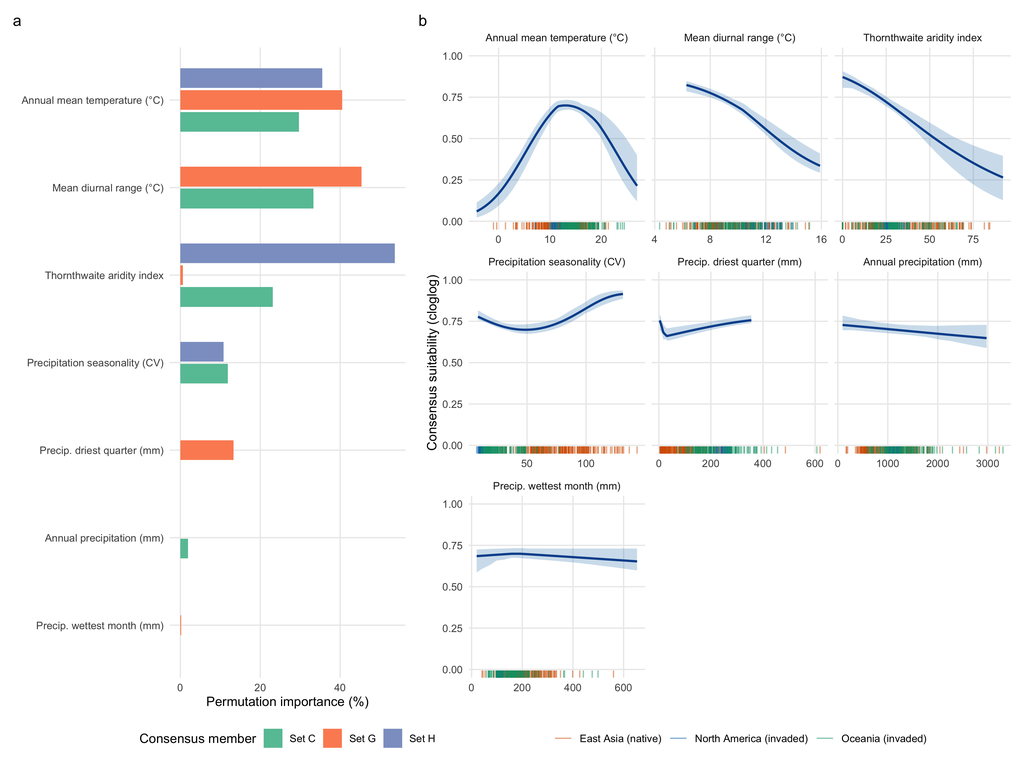

Figure 2: Predictor importance and responses in the consensus model. (a) Permutation importance of each predictor in each consensus member (predictors absent from a member have no bar). (b) Marginal response curves of the consensus (mean cloglog suitability of the three members), with other predictors held at their median across presences; the line is the fitted consensus and the ribbon the 95% interval across 30 bootstrap replicates. Rugs show the predictor values at presence records, coloured by region.

```r
lvl <- var_lab[imp_order$variable]
p_imp <- var_imp |> mutate(variable = factor(var_lab[variable], levels = rev(lvl)), set = paste("Set", set)) |>
  ggplot(aes(permutation, variable, fill = set)) +
  geom_col(position = position_dodge2(preserve = "single", width = 0.8), width = 0.75) +
  scale_fill_brewer(palette = "Set2", name = "Consensus member") +
  labs(x = "Permutation importance (%)", y = NULL, tag = "a") + theme(legend.position = "bottom")

med <- occ |> summarise(across(all_of(sel_vars), median))
resp_grid <- map_dfr(sel_vars, function(v) {
  rng <- quantile(c(occ[[v]], bg_train[[v]]), c(0.005, 0.995))
  nd <- med[rep(1, 200), ]; nd[[v]] <- seq(rng[1], rng[2], length.out = 200)
  boot <- sapply(boot_models, ens_pred_df, x = nd)
  tibble(variable = v, x = nd[[v]], fit = ens_pred_df(m_final, nd),
         lo = apply(boot, 1, quantile, 0.025), hi = apply(boot, 1, quantile, 0.975))
}) |> mutate(variable = factor(var_lab[variable], levels = lvl))
rug_df <- occ |> dplyr::select(region, all_of(sel_vars)) |> pivot_longer(-region, names_to = "variable", values_to = "x") |>
  mutate(variable = factor(var_lab[variable], levels = lvl))
p_resp <- ggplot(resp_grid, aes(x)) +
  geom_ribbon(aes(ymin = lo, ymax = hi), fill = "#2c7fb8", alpha = 0.25) +
  geom_line(aes(y = fit), colour = "#08519c", linewidth = 0.9) +
  geom_rug(data = rug_df, aes(x = x, colour = region), sides = "b", alpha = 0.5, length = unit(0.04, "npc")) +
  scale_colour_manual(values = reg_col, labels = reg_lab, name = NULL) +
  facet_wrap(~ variable, scales = "free_x", ncol = 3) +
  coord_cartesian(ylim = c(0, 1)) +
  labs(x = NULL, y = "Consensus suitability (cloglog)", tag = "b") + theme(legend.position = "bottom")
p_fig2 <- p_imp + p_resp + plot_layout(widths = c(1, 2.3))
p_fig2
save_fig("Fig2_importance_response", p_fig2, 12, 9)
```

## 3.5 Current climatic suitability of Australia and New Zealand

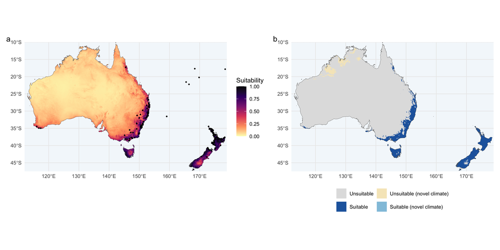

Figure 3: Current climatic suitability for *Haemaphysalis longicornis* in Australia and New Zealand. (a) Continuous cloglog suitability with known Oceanian records (training records and ALA records; black points). (b) Binary suitability at the 10th-percentile training-presence threshold; pale colours indicate cells with climates outside the calibration range (MESS < 0).

```r
aunz_sf <- world10 |> filter(admin %in% c("Australia", "New Zealand"))
bin_cls <- (suit_bin + 1) + 2 * (mess_r < 0)       # 1 unsuitable, 2 suitable, 3 unsuitable-novel, 4 suitable-novel
bin_cls <- as.factor(bin_cls)
levels(bin_cls) <- data.frame(ID = 1:4, class = c("Unsuitable", "Suitable", "Unsuitable (novel climate)", "Suitable (novel climate)"))
map_base <- list(coord_sf(xlim = c(112, 179), ylim = c(-47.5, -10), expand = FALSE),
                 labs(x = NULL, y = NULL), theme(panel.background = element_rect(fill = "#f4f8fb", colour = NA)))
p_cont <- ggplot() +
  geom_spatraster(data = pred_cur, maxcell = 2e6) +
  scale_fill_viridis_c(option = "magma", direction = -1, limits = c(0, 1), na.value = NA, name = "Suitability") +
  geom_sf(data = aunz_sf, fill = NA, colour = "grey40", linewidth = 0.15) +
  geom_point(data = known, aes(lon, lat), size = 0.6, colour = "black") +
  map_base + labs(tag = "a")
p_bin <- ggplot() +
  geom_spatraster(data = bin_cls, maxcell = 2e6) +
  scale_fill_manual(values = c("Unsuitable" = "grey88", "Suitable" = "#2166ac",
                               "Unsuitable (novel climate)" = "#f6e8c3", "Suitable (novel climate)" = "#92c5de"),
                    na.value = NA, na.translate = FALSE, name = NULL, drop = FALSE) +
  geom_sf(data = aunz_sf, fill = NA, colour = "grey40", linewidth = 0.15) +
  map_base + labs(tag = "b") + theme(legend.position = "bottom") + guides(fill = guide_legend(nrow = 2))
p_fig3 <- p_cont + p_bin
p_fig3
save_fig("Fig3_current_suitability", p_fig3, 12, 6)
```

```r
area_print <- area_tab |>
  transmute(Jurisdiction = jurisdiction, `Land (km²)` = fmt_int(land_km2), `Suitable (km²)` = fmt_int(suitable_km2),
            `Suitable (%)` = fmt(pct_suitable, 1), `Suitable, analogue (km²)` = fmt_int(suitable_analog_km2),
            `Suitable but unrecorded (km²)` = fmt_int(gap_km2))
kable(area_print, align = "lrrrrr")
```

Table 2: Land area classified as climatically suitable for *H. longicornis* by jurisdiction (10th-percentile training-presence threshold). *Suitable (analogue)* excludes cells with novel climate (MESS < 0). *Suitable but unrecorded* is suitable area more than 100 km from any known record.

| Jurisdiction | Land (km²) | Suitable (km²) | Suitable (%) | Suitable, analogue (km²) | Suitable but unrecorded (km²) |
| --- | --- | --- | --- | --- | --- |
| New South Wales | 801,994 | 166,116 | 20.7 | 166,116 | 2,234 |
| NZ South Island | 151,728 | 143,490 | 94.6 | 143,220 | 84,375 |
| NZ North Island | 114,052 | 114,052 | 100.0 | 114,052 | 0 |
| Victoria | 228,308 | 90,555 | 39.7 | 90,555 | 23,058 |
| Tasmania | 68,201 | 66,640 | 97.7 | 66,640 | 66,640 |
| Queensland | 1,729,947 | 45,196 | 2.6 | 45,196 | 12,342 |
| South Australia | 983,402 | 7,446 | 0.8 | 7,446 | 7,446 |
| Western Australia | 2,528,492 | 4,905 | 0.2 | 4,905 | 55 |
| Australian Capital Territory | 2,307 | 1,082 | 46.9 | 1,082 | 0 |
| Northern Territory | 1,348,325 | 0 | 0.0 | 0 | 0 |

## 3.6 Niche comparison between native and invaded ranges

In the climatic space defined by the model predictors (first two PCA axes explaining 72% of the variation), the Oceanian and native niches overlapped moderately (Schoener’s *D* = 0.47). Niche equivalency could not be rejected (P = 1.00), and the Oceanian niche was more similar to the native niche than expected from the climates available in Oceania (P = 0.030; Table S5, Figure S8). Within climates shared by both ranges, 86% of the Oceanian niche coincided with the native niche (stability). Expansion into climates unused in the native range was limited (14%). It was directed towards wet climates with evenly distributed rainfall and substantial dry-season precipitation (high PC2; low BIO15, high BIO17), typical of New Zealand and coastal south-eastern Australia (Figure 4 a). About a third of the native niche was unfilled in Oceania (31%). This part corresponds to drier, strongly seasonal summer-rainfall climates with dry winters and larger diurnal temperature ranges (high PC1, low PC2), characteristic of northern and inland China. In contrast, the North American niche overlapped very little with the native niche (*D* = 0.06) and was not equivalent to it (P = 0.010). This was not because of expansion into novel climates. Rather, North American records occupy a small part of the climates available there, leaving 96% of the native niche unfilled (Figure 4 b).

```r
par(mfrow = c(1, 2), mar = c(4, 4, 3, 1))
for (inv in c("Oceania", "North_America")) {
  ecospat.plot.niche.dyn(z[["East_Asia"]], z[[inv]], quant = 0.25, interest = 2,
                         title = paste(ifelse(inv == "Oceania", "(a)", "(b)"), "East Asia vs.", gsub("_", " ", inv)),
                         name.axis1 = sprintf("PC1 (%.0f%%)", 100 * pca$eig[1] / sum(pca$eig)),
                         name.axis2 = sprintf("PC2 (%.0f%%)", 100 * pca$eig[2] / sum(pca$eig)))
  ecospat.shift.centroids(sc_occ[occ$region == "East_Asia", ], sc_occ[occ$region == inv, ],
                          sc_bg[bg_eval$region == "East_Asia", ], sc_bg[bg_eval$region == inv, ])
}
png(file.path(fig_dir, "Fig4_niche_dynamics.png"), width = 11, height = 5.5, units = "in", res = 300)
par(mfrow = c(1, 2), mar = c(4, 4, 3, 1))
for (inv in c("Oceania", "North_America")) {
  ecospat.plot.niche.dyn(z[["East_Asia"]], z[[inv]], quant = 0.25, interest = 2,
                         title = paste(ifelse(inv == "Oceania", "(a)", "(b)"), "East Asia vs.", gsub("_", " ", inv)),
                         name.axis1 = "PC1", name.axis2 = "PC2")
  ecospat.shift.centroids(sc_occ[occ$region == "East_Asia", ], sc_occ[occ$region == inv, ],
                          sc_bg[bg_eval$region == "East_Asia", ], sc_bg[bg_eval$region == inv, ])
}
```

[output not shown]

[output not shown]

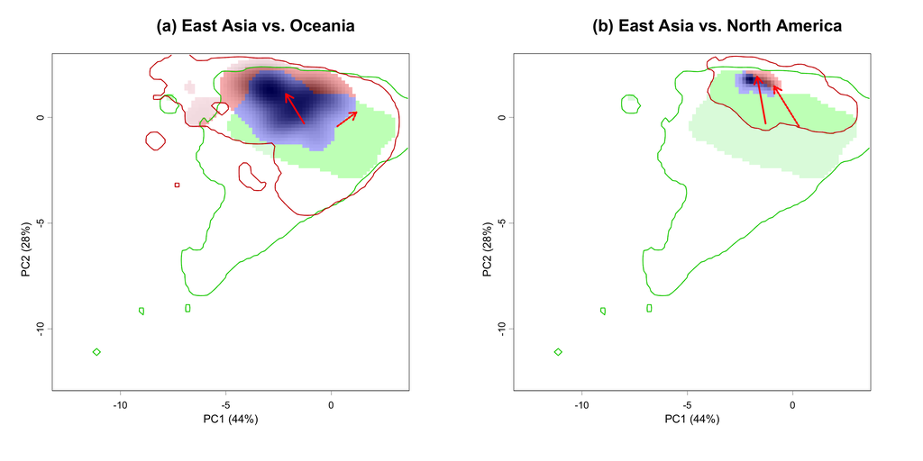

Figure 4: Niche dynamics of *H. longicornis* in climatic space (first two PCA axes of the model predictors, calibrated on the background of all regions). Blue = niche stability (climates occupied in both ranges); red = expansion (occupied only in the invaded range); green = unfilling (occupied only in the native range); colour intensity reflects occurrence density. Green and red contours delimit the climates available in the native and invaded ranges, respectively (100%, and 75% for the paler line). Arrows show the shift from the native to the invaded niche centroid (solid) and background centroid (dashed). (a) East Asia vs. Oceania; (b) East Asia vs. North America.

```r
invisible(dev.off())
```

## 3.7 Limiting factors and surveillance gaps

Aridity was the most limiting factor across most of inland Australia. Mean diurnal temperature range was limiting along the western slopes and tablelands of the Great Dividing Range, immediately inland of the suitable eastern belt. High annual mean temperature was limiting across the tropical north (Figure 5 a). In Tasmania, the South Island and upland areas of New Zealand, low annual mean temperature was the main factor reducing suitability below its optimum, although most of these areas still exceeded the suitability threshold. Of the suitable area, 208,388 km² (31%) lay more than 100 km from any known Oceanian record (Figure 5 b; Table 2). Most of this was in the NZ South Island (84,375 km²), Tasmania (66,640 km²), western and coastal Victoria (23,058 km²), coastal Queensland north of the main known range (12,342 km²) and the south-east of South Australia (7,446 km²).

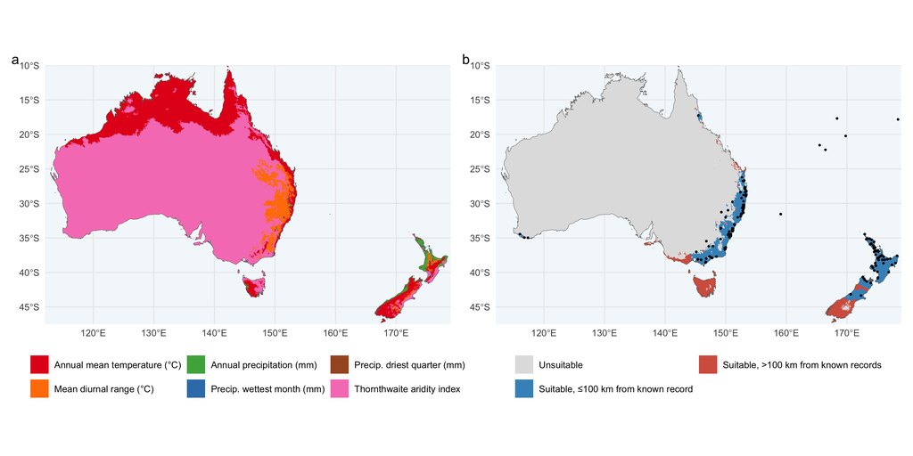

Figure 5: (a) Most limiting climatic factor in each grid cell (the predictor whose adjustment to its median value at presence records would most increase suitability; Elith et al. 2010). (b) Suitable climate relative to known records: suitable cells within 100 km of a known Oceanian record, and suitable cells more than 100 km from any known record (candidate surveillance areas).

```r
lim_f <- as.factor(limit_r)
levels(lim_f) <- data.frame(ID = seq_along(sel_vars), factor = var_lab[sel_vars])
lim_cols <- setNames(c("#e41a1c", "#ff7f00", "#4daf4a", "#377eb8", "#984ea3", "#a65628", "#f781bf", "#999999")[seq_along(sel_vars)], var_lab[sel_vars])
p_lim <- ggplot() + geom_spatraster(data = lim_f, maxcell = 2e6) +
  scale_fill_manual(values = lim_cols, na.value = NA, na.translate = FALSE, name = NULL) +
  geom_sf(data = aunz_sf, fill = NA, colour = "grey40", linewidth = 0.15) +
  map_base + labs(tag = "a") + theme(legend.position = "bottom") + guides(fill = guide_legend(nrow = 2))
gap_f <- as.factor(gap_r)
levels(gap_f) <- data.frame(ID = 0:2, class = c("Unsuitable", "Suitable, ≤100 km from known record", "Suitable, >100 km from known records"))
p_gap <- ggplot() + geom_spatraster(data = gap_f, maxcell = 2e6) +
  scale_fill_manual(values = c("grey88", "#4393c3", "#d6604d"), na.value = NA, na.translate = FALSE, name = NULL) +
  geom_sf(data = aunz_sf, fill = NA, colour = "grey40", linewidth = 0.15) +
  geom_point(data = known, aes(lon, lat), size = 0.5, colour = "black") +
  map_base + labs(tag = "b") + theme(legend.position = "bottom") + guides(fill = guide_legend(nrow = 2))
p_fig5 <- p_lim + p_gap
p_fig5
save_fig("Fig5_limiting_factors_gaps", p_fig5, 12, 6)
```

# 4 Discussion

We developed a consensus species distribution model for *H. longicornis* that was selected for, and demonstrably capable of, transfer between continents. Trained without any Oceanian records, it reproduced the known Australian and New Zealand distribution, ranking occupied sites far above available environments (AUC = 0.91; Boyce index = 0.94). Fitted to all records, the model indicates that current climate permits *H. longicornis* across 668,870 km² of Australia and New Zealand. This area is concentrated on the humid, thermally equable eastern seaboard of Australia, Tasmania and almost all of New Zealand, and is bounded inland by aridity and continental temperature regimes and to the north by heat.

## 4.1 Transferability depends on predictors and sampling design

Two methodological choices largely determined whether the model transferred. The first was the treatment of sampling bias. GBIF tick records, the usual source of target-group background, are dominated by North American data. A single global sampling-effort surface would therefore place most background points in North America and contrast East Asian and Oceanian presences against very few local background points. Normalising sampling effort within regions and allocating background in proportion to area keeps the correction for survey intensity within regions without letting differences in data volume among countries dominate the fitted niche. Predictions were nearly identical with a uniform background (Spearman ρ = 0.96; Figure S9), so the conclusions do not depend on the details of the bias surface.

The second was the predictor set. Automated stepwise VIF selection removed every absolute temperature variable because temperature is strongly collinear with VPD, PET and the thermal extremes. The resulting predictor set (set A) discriminated well within withheld regions but failed to transfer suitability levels: with Oceania withheld, 100% of Oceanian records fell below the training threshold. Correlated variables such as VPD and isothermality can stand in for temperature within a calibration region, but the relationships among them differ between continents. Only a direct thermal gradient constrains predictions consistently. This is biologically expected. Development rates, questing activity and overwinter survival of ixodid ticks are governed by temperature, and off-host survival is governed by the atmospheric moisture balance (Needham and Teel 1991; Heath 2016). The three predictor sets retained in the consensus each pair annual mean temperature with a moisture or desiccation axis, which matches this mechanistic expectation. Our results add to evidence that selecting predictors on ecological grounds and evaluating models by transfer, rather than by collinearity screening and within-region cross-validation alone, gives more reliable models for invasive species (Wenger and Olden 2012; Dormann et al. 2013; Valavi et al. 2022).

## 4.2 Climatic limits in Australia and New Zealand

The predicted Australian range matches the documented distribution of the tick along the eastern coast and in Victoria (Hoogstraal et al. 1968; Heath 2016), and it captures the outlying south-western Western Australian and north Queensland records. Inland, suitability is limited first by large diurnal temperature ranges along the western fall of the Great Dividing Range and then by aridity across the interior. Both reflect the vulnerability of non-feeding stages to desiccation (Needham and Teel 1991). In the tropical north, high mean temperatures limit suitability. Here the native-range evidence is clear: *H. longicornis* is absent from the tropical lowlands of southern China and South-East Asia. The few tropical records from Pacific islands come from small, maritime, highly humid environments that have no counterpart in northern Australia. New Zealand is almost entirely suitable, consistent with the tick’s long-established distribution across the North Island and its presence in parts of the South Island (Heath 2016). Low annual mean temperature is the main factor reducing suitability in the south and at altitude.

## 4.3 Niche conservatism and its implications

The Oceanian niche was equivalent to and more similar than expected to the native niche, with high stability and limited expansion. This is consistent with the general pattern that climatic niches are largely conserved during invasion (Petitpierre et al. 2012; Guisan et al. 2014), and it explains why native-range information transferred well to Australia and New Zealand. The unfilled part of the native niche consists of drier, strongly seasonal summer-rainfall climates. In Australia, comparable rainfall regimes occur mainly in the monsoonal north, where temperatures exceed the species’ optimum, so unfilling probably reflects how climate axes combine in Oceania rather than an inability of the invasive lineage to tolerate these conditions. The very low overlap with the North American niche has a different cause. Records there cover a small subset of the available climates, which is the expected signature of a population still spreading after its detection in 2017 (Rainey et al. 2018), rather than a genuine niche shift. Because the North American population is far from equilibrium, models calibrated only on North American records would greatly underestimate the species’ climatic tolerance. Transfer to East Asia was the weakest in our cross-validation for the same reason: the invaded ranges sample only part of the native niche. Pooling all three ranges, as done here, is therefore preferable to calibrating on either native or invaded records alone.

## 4.4 Implications for surveillance

About 31% of the suitable area lies more than 100 km from any record in our dataset, mostly in Tasmania, the South Island of New Zealand, western and coastal Victoria and south-eastern South Australia. These areas are climatically comparable to the core of the established range, carry large livestock populations, and are connected to infested regions by stock movements. They are logical targets for structured surveillance. A lack of records in these areas should not be taken as evidence of absence: our compilation relies on opportunistic and published records, and some suitable areas may already be occupied but under-reported. Conversely, surveillance resources are unlikely to be well spent in the arid and tropical interior, where climate is unsuitable with high confidence and with little extrapolation.

## 4.5 Limitations

Several limitations should be borne in mind. First, the model describes climatic suitability at a resolution of about 5 km. It does not account for vegetation, microclimate, host availability (particularly cattle density) or land use, all of which determine local tick abundance. The binary maps therefore indicate where populations could persist climatically, not where the tick is present or abundant. Second, cloglog output is a relative index of suitability, and binary maps depend on the threshold. The 10th-percentile training-presence threshold is deliberately inclusive of most known records, but the alternative threshold changes the suitable area (Table S4). Third, the target-group data used to correct for sampling bias are themselves uneven, particularly in East Asia. The close agreement with a uniform background suggests this has little effect on predictions. Fourth, bisexual and parthenogenetic populations were pooled. The invaded populations are parthenogenetic, and if the two forms differ in climatic tolerance, the invaded-range niche may be better represented by the subset of native localities occupied by parthenogenetic populations (Hoogstraal et al. 1968). Fifth, omission under spatial-block cross-validation (OR10 = 0.18) was above the nominal 0.10, indicating some residual over-fitting, and transfer to the native range was weaker than to the invaded ranges. Finally, this analysis addresses current climate only. Projecting these relationships to future climates will require attention to extrapolation, because several predictors will move outside the calibration range across northern and inland Australia (Elith, Kearney, and Phillips 2010; Owens et al. 2013).

## 4.6 Conclusions

The climatic niche of *H. longicornis* has been conserved during its invasion of Australia and New Zealand, and a model calibrated across all ranges predicts its distribution there accurately, provided the model includes an absolute temperature gradient and corrects for regional imbalance in sampling effort. Suitable climate is concentrated on the eastern seaboard of Australia, in Tasmania and across New Zealand, and is limited inland by aridity and continental temperature regimes. The climatically suitable but apparently unoccupied areas identified here, especially Tasmania and southern New Zealand, should be prioritised for surveillance. The transferability-based framework used here provides a defensible baseline for future projections under climate change.

# References

Barve, Narayani, Vijay Barve, Alberto Jiménez-Valverde, Andrés Lira-Noriega, Sean P. Maher, A. Townsend Peterson, Jorge Soberón, and Fabricio Villalobos. 2011. “The Crucial Role of the Accessible Area in Ecological Niche Modeling and Species Distribution Modeling.” *Ecological Modelling* 222: 1810–19.

Broennimann, Olivier, Matthew C. Fitzpatrick, Peter B. Pearman, Blaise Petitpierre, Loïc Pellissier, Nigel G. Yoccoz, Wilfried Thuiller, et al. 2012. “Measuring Ecological Niche Overlap from Occurrence and Spatial Environmental Data.” *Global Ecology and Biogeography* 21: 481–97.

Di Cola, Valeria, Olivier Broennimann, Blaise Petitpierre, Frank T. Breiner, Manuela D’Amen, Christophe Randin, Robin Engler, et al. 2017. “Ecospat: An R Package to Support Spatial Analyses and Modeling of Species Niches and Distributions.” *Ecography* 40: 774–87.

Dormann, Carsten F., Jane Elith, Sven Bacher, Carsten Buchmann, Gudrun Carl, Gabriel Carré, Jaime R. García Marquéz, et al. 2013. “Collinearity: A Review of Methods to Deal with It and a Simulation Study Evaluating Their Performance.” *Ecography* 36: 27–46.

Elith, Jane, Michael Kearney, and Steven Phillips. 2010. “The Art of Modelling Range-Shifting Species.” *Methods in Ecology and Evolution* 1: 330–42.

Fick, Stephen E., and Robert J. Hijmans. 2017. “WorldClim 2: New 1-Km Spatial Resolution Climate Surfaces for Global Land Areas.” *International Journal of Climatology* 37: 4302–15.

Guisan, Antoine, Blaise Petitpierre, Olivier Broennimann, Curtis Daehler, and Christoph Kueffer. 2014. “Unifying Niche Shift Studies: Insights from Biological Invasions.” *Trends in Ecology & Evolution* 29: 260–69.

Heath, Allen. 2016. “Biology, Ecology and Distribution of the Tick, *Haemaphysalis Longicornis* Neumann (Acari: Ixodidae) in New Zealand.” *New Zealand Veterinary Journal* 64: 10–20.

Hirzel, Alexandre H., Gwenaëlle Le Lay, Véronique Helfer, Christophe Randin, and Antoine Guisan. 2006. “Evaluating the Ability of Habitat Suitability Models to Predict Species Presences.” *Ecological Modelling* 199: 142–52.

Hoogstraal, Harry, F. H. S. Roberts, Glen M. Kohls, and Vernon J. Tipton. 1968. “Review of *Haemaphysalis* (*Kaiseriana*) *Longicornis* Neumann (Resurrected) of Australia, New Zealand, New Caledonia, Fiji, Japan, Korea, and Northeastern China and USSR, and Its Parthenogenetic and Bisexual Populations (Ixodoidea, Ixodidae).” *Journal of Parasitology* 54: 1197–1213.

Kamau, Joseph, Albert J. de Vos, Martin Playford, Basima Salim, Peter Kinyanjui, and Chihiro Sugimoto. 2011. “Emergence of New Types of *Theileria Orientalis* in Australian Cattle and Possible Cause of Theileriosis Outbreaks.” *Parasites & Vectors* 4: 22.

Karger, Dirk Nikolaus, Olaf Conrad, Jürgen Böhner, Tobias Kawohl, Holger Kreft, Rodrigo Wilber Soria-Auza, Niklaus E. Zimmermann, H. Peter Linder, and Michael Kessler. 2017. “Climatologies at High Resolution for the Earth’s Land Surface Areas.” *Scientific Data* 4: 170122.

Kass, Jamie M., Robert Muscarella, Peter J. Galante, Corentin L. Bohl, Gonzalo E. Pinilla-Buitrago, Robert A. Boria, Mariano Soley-Guardia, and Robert P. Anderson. 2021. “ENMeval 2.0: Redesigned for Customizable and Reproducible Modeling of Species’ Niches and Distributions.” *Methods in Ecology and Evolution* 12: 1602–8.

Liu, Canran, Matt White, and Graeme Newell. 2013. “Selecting Thresholds for the Prediction of Species Occurrence with Presence-Only Data.” *Journal of Biogeography* 40: 778–89.

Namgyal, Jamyang, Isabelle Couloigner, Tim J. Lysyk, Shaun J. Dergousoff, and Susan C. Cork. 2020. “Comparison of Habitat Suitability Models for *Haemaphysalis Longicornis* Neumann in North America to Determine Its Potential Geographic Range.” *International Journal of Environmental Research and Public Health* 17: 8285.

Needham, Glen R., and Pete D. Teel. 1991. “Off-Host Physiological Ecology of Ixodid Ticks.” *Annual Review of Entomology* 36: 659–81.

Owens, Hannah L., Lindsay P. Campbell, L. Lynnette Dornak, Erin E. Saupe, Narayani Barve, Jorge Soberón, Kate Ingenloff, et al. 2013. “Constraints on Interpretation of Ecological Niche Models by Limited Environmental Ranges on Calibration Areas.” *Ecological Modelling* 263: 10–18.

Petitpierre, Blaise, Christoph Kueffer, Olivier Broennimann, Christophe Randin, Curtis Daehler, and Antoine Guisan. 2012. “Climatic Niche Shifts Are Rare Among Terrestrial Plant Invaders.” *Science* 335: 1344–48.

Phillips, Steven J., Robert P. Anderson, Miroslav Dudík, Robert E. Schapire, and Mary E. Blair. 2017. “Opening the Black Box: An Open-Source Release of Maxent.” *Ecography* 40: 887–93.

Phillips, Steven J., Robert P. Anderson, and Robert E. Schapire. 2006. “Maximum Entropy Modeling of Species Geographic Distributions.” *Ecological Modelling* 190: 231–59.

Phillips, Steven J., Miroslav Dudík, Jane Elith, Catherine H. Graham, Anthony Lehmann, John Leathwick, and Simon Ferrier. 2009. “Sample Selection Bias and Presence-Only Distribution Models: Implications for Background and Pseudo-Absence Data.” *Ecological Applications* 19: 181–97.

Radosavljevic, Aleksandar, and Robert P. Anderson. 2014. “Making Better Maxent Models of Species Distributions: Complexity, Overfitting and Evaluation.” *Journal of Biogeography* 41: 629–43.

Raghavan, Ram K., Stephen C. Barker, Marlon E. Cobos, Dayana Barker, E. J. M. Teo, David H. Foley, Ryo Nakao, Kevin Lawrence, Allen C. G. Heath, and A. Townsend Peterson. 2019. “Potential Spatial Distribution of the Newly Introduced Long-Horned Tick, *Haemaphysalis Longicornis* in North America.” *Scientific Reports* 9: 498.

Rainey, Tadhgh, James L. Occi, Richard G. Robbins, and Andrea Egizi. 2018. “Discovery of *Haemaphysalis Longicornis* (Ixodida: Ixodidae) Parasitizing a Sheep in New Jersey, United States.” *Journal of Medical Entomology* 55: 757–59.

Roberts, David R., Volker Bahn, Simone Ciuti, Mark S. Boyce, Jane Elith, Gurutzeta Guillera-Arroita, Severin Hauenstein, et al. 2017. “Cross-Validation Strategies for Data with Temporal, Spatial, Hierarchical, or Phylogenetic Structure.” *Ecography* 40: 913–29.

Rochlin, Ilia. 2019. “Modeling the Asian Longhorned Tick (Acari: Ixodidae) Suitable Habitat in North America.” *Journal of Medical Entomology* 56: 384–91.

Title, Pascal O., and Jordan B. Bemmels. 2018. “ENVIREM: An Expanded Set of Bioclimatic and Topographic Variables Increases Flexibility and Improves Performance of Ecological Niche Modeling.” *Ecography* 41: 291–307.

Valavi, Roozbeh, Gurutzeta Guillera-Arroita, José J. Lahoz-Monfort, and Jane Elith. 2022. “Predictive Performance of Presence-Only Species Distribution Models: A Benchmark Study with Reproducible Code.” *Ecological Monographs* 92: e01486.

Warren, Dan L., Richard E. Glor, and Michael Turelli. 2008. “Environmental Niche Equivalency Versus Conservatism: Quantitative Approaches to Niche Evolution.” *Evolution* 62: 2868–83.

Wenger, Seth J., and Julian D. Olden. 2012. “Assessing Transferability of Ecological Models: An Underappreciated Aspect of Statistical Validation.” *Methods in Ecology and Evolution* 3: 260–67.

Yu, Xue-Jie, Mi-Fang Liang, Shou-Yin Zhang, Yan Liu, Jian-Dong Li, Yu-Lan Sun, Lihong Zhang, et al. 2011. “Fever with Thrombocytopenia Associated with a Novel Bunyavirus in China.” *New England Journal of Medicine* 364: 1523–32.

Zhang, Guoyu, Dan Zheng, Yunhe Tian, and Sen Li. 2019. “A Dataset of Distribution and Diversity of Ticks in China.” *Scientific Data* 6: 105.

Zhao, Lin, Jie Li, Xiaoming Cui, Na Jia, Jiate Wei, Luoyuan Xia, Hongtao Wang, et al. 2020. “Distribution of *Haemaphysalis Longicornis* and Associated Pathogens: Analysis of Pooled Data from a China Field Survey and Global Published Data.” *The Lancet Planetary Health* 4: e320–29.

## 5 Supplementary material

## 5.1 Supplementary tables

```r
occ |> count(region, country) |> mutate(region = reg_lab[region]) |>
  arrange(region, desc(n)) |> rename(Region = region, Country = country, Records = n) |> kable()
```

| Region | Country | Records |
| --- | --- | --- |
| East Asia (native) | China | 166 |
| East Asia (native) | Japan | 21 |
| East Asia (native) | South Korea | 20 |
| East Asia (native) | Russia | 5 |
| East Asia (native) | India | 1 |
| East Asia (native) | North Korea | 1 |
| East Asia (native) | Taiwan | 1 |
| North America (invaded) | United States of America | 53 |
| Oceania (invaded) | Australia | 67 |
| Oceania (invaded) | New Zealand | 48 |
| Oceania (invaded) | New Caledonia | 2 |
| Oceania (invaded) | Fiji | 1 |
| Oceania (invaded) | Samoa | 1 |
| Oceania (invaded) | Tonga | 1 |
| Oceania (invaded) | Vanuatu | 1 |

Table S1: Occurrence records used for calibration by region and country.

```r
best_by_set |>
  transmute(Set = set, Description = set_desc[set], Variables = map_chr(cand_sets[set], paste, collapse = ", "),
            `max |ρ|` = set_coll$max_abs_rho[match(set, set_coll$set)], `max VIF` = set_coll$max_VIF[match(set, set_coll$set)],
            `Best FC` = fc, `Best β` = rm, `LORO AUC` = loro_auc, `LORO CBI` = loro_cbi, `LORO OR10` = loro_or10,
            `Block AUC` = blk_auc, `Block CBI` = blk_cbi, `Block OR10` = blk_or10,
            `Passes omission filter` = ifelse(pass, "yes", "no"), `Rank sum` = rank_sum) |>
  kable(digits = 3)
```

[output not shown]

```r
cv_final |> mutate(fold = ifelse(scheme == "loro", reg_lab[fold], paste("Block fold", fold)),
                   scheme = ifelse(scheme == "loro", "Leave-one-region-out", "Spatial block")) |>
  rename(Scheme = scheme, `Test fold` = fold, `n test` = n_test, AUC = auc, CBI = cbi, OR10 = or10) |>
  kable(digits = 3)
```

| Scheme | Test fold | n test | AUC | CBI | OR10 |
| --- | --- | --- | --- | --- | --- |
| Leave-one-region-out | East Asia (native) | 215 | 0.740 | 0.512 | 0.512 |
| Leave-one-region-out | North America (invaded) | 53 | 0.918 | 0.994 | 0.000 |
| Leave-one-region-out | Oceania (invaded) | 121 | 0.915 | 0.936 | 0.306 |
| Spatial block | Block fold 1 | 75 | 0.864 | 0.896 | 0.133 |
| Spatial block | Block fold 2 | 85 | 0.768 | 0.780 | 0.329 |
| Spatial block | Block fold 3 | 19 | 0.872 | 0.940 | 0.263 |
| Spatial block | Block fold 4 | 67 | 0.881 | 0.838 | 0.030 |
| Spatial block | Block fold 5 | 143 | 0.693 | 0.744 | 0.133 |

Table S3: Cross-validation results for the consensus model by fold.

```r
tibble(Threshold = c("10th-percentile training presence (primary)", "Maximum sensitivity + specificity (vs. evaluation background)"),
       `Cloglog value` = c(thr_p10, thr_mss),
       `Suitable area, Aus + NZ (km²)` = fmt_int(c(tot[["suitable"]], global(carea * (pred_cur >= thr_mss), "sum", na.rm = TRUE)[[1]])),
       `Records predicted suitable (%)` = 100 * c(mean(p_occ >= thr_p10), mean(p_occ >= thr_mss))) |>
  kable(digits = 3)
```

| Threshold | Cloglog value | Suitable area, Aus + NZ (km²) | Records predicted suitable (%) |
| --- | --- | --- | --- |
| 10th-percentile training presence (primary) | 0.400 | 668,870 | 89.974 |
| Maximum sensitivity + specificity (vs. evaluation background) | 0.463 | 571,387 | 85.347 |

Table S4: Alternative suitability thresholds and their consequences.

```r
niche_tab |> rename(Comparison = comparison, `Schoener's D` = D, `P (equivalency; non-equivalence)` = p_equivalency,
                    `P (similarity)` = p_similarity, Stability = stability, Expansion = expansion, Unfilling = unfilling) |>
  kable(digits = 3)
```

| Comparison | Schoener’s D | P (equivalency; non-equivalence) | P (similarity) | Stability | Expansion | Unfilling |
| --- | --- | --- | --- | --- | --- | --- |
| East Asia (native) vs Oceania (invaded) | 0.468 | 1.00 | 0.030 | 0.858 | 0.142 | 0.311 |
| East Asia (native) vs North America (invaded) | 0.056 | 0.01 | 0.366 | 0.689 | 0.311 | 0.962 |

Table S5: Niche overlap, equivalency and similarity tests (100 randomisations), and niche dynamics indices (computed in analogue climates; intersection = 0.1) between the native and each invaded range. The equivalency test evaluates whether overlap is lower than expected if occurrences were interchangeable between ranges; the similarity test evaluates whether overlap is higher than expected given the climates available in the invaded range.

## 5.2 Supplementary figures

```r
cor_df <- as.data.frame(as.table(cor_bg)) |> mutate(across(1:2, ~ factor(.x, levels = cand_vars)))
ggplot(cor_df, aes(Var1, Var2, fill = Freq)) + geom_tile(colour = "white") +
  geom_text(aes(label = sprintf("%.2f", Freq)), size = 2.3) +
  scale_fill_gradient2(low = "#b2182b", high = "#2166ac", limits = c(-1, 1), name = "Spearman ρ") +
  labs(x = NULL, y = NULL) + theme(axis.text.x = element_text(angle = 45, hjust = 1))
```

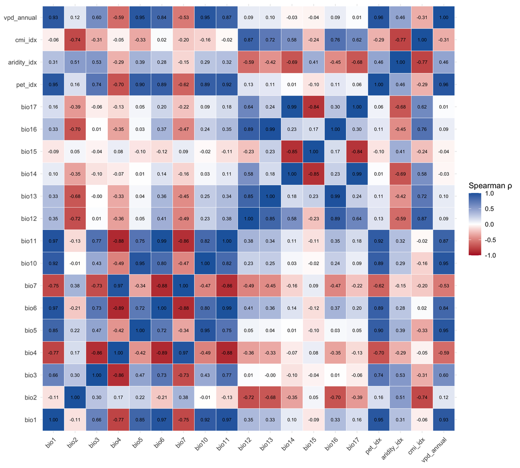

Figure S1: Spearman correlations among the 19 candidate predictors across the accessible area (evaluation background, n = 9,996).

```r
save_fig("FigS1_predictor_correlation", w = 10, h = 9)
```

```r
bias_df <- as.data.frame(aggregate(bias_r, 4, mean, na.rm = TRUE), xy = TRUE, na.rm = TRUE)
ggplot() + geom_sf(data = world50, fill = "grey95", colour = "grey75", linewidth = 0.1) +
  geom_tile(data = bias_df, aes(x, y, fill = bias)) +
  scale_fill_viridis_c(option = "inferno", trans = "sqrt", name = "Relative\nsampling effort") +
  geom_point(data = bg_train, aes(lon, lat), size = 0.05, alpha = 0.25, colour = "cyan") +
  coord_sf(xlim = c(-180, 180), ylim = c(-55, 75), expand = FALSE) + labs(x = NULL, y = NULL)
```

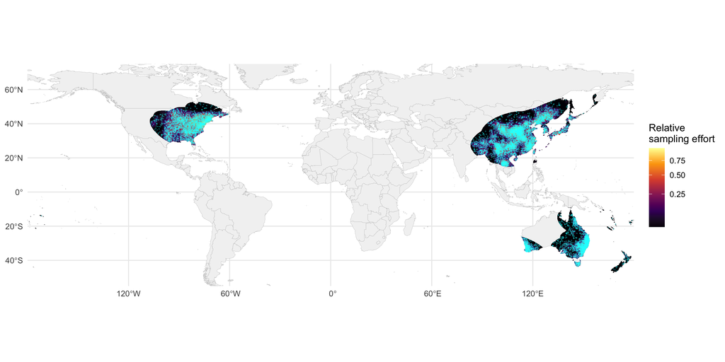

Figure S2: Target-group sampling-effort surface (kernel density of Ixodidae records, normalised within each region) and the resulting bias-corrected training background points (cyan; n = 9,995).

```r
save_fig("FigS2_bias_surface", w = 11, h = 5.5)
```

```r
dens_df <- bind_rows(occ |> mutate(type = "Presence") |> dplyr::select(region, type, all_of(sel_vars)),
                     bg_eval |> mutate(type = "Available (M)") |> dplyr::select(region, type, all_of(sel_vars))) |>
  pivot_longer(all_of(sel_vars), names_to = "variable") |> mutate(variable = var_lab[variable], region = reg_lab[region])
ggplot(dens_df, aes(value, fill = type)) + geom_density(alpha = 0.5, colour = NA) +
  facet_grid(region ~ variable, scales = "free") + scale_fill_manual(values = c("grey60", "#d6604d"), name = NULL) +
  labs(x = NULL, y = "Density") + theme(legend.position = "bottom", strip.text = element_text(size = 8))
```

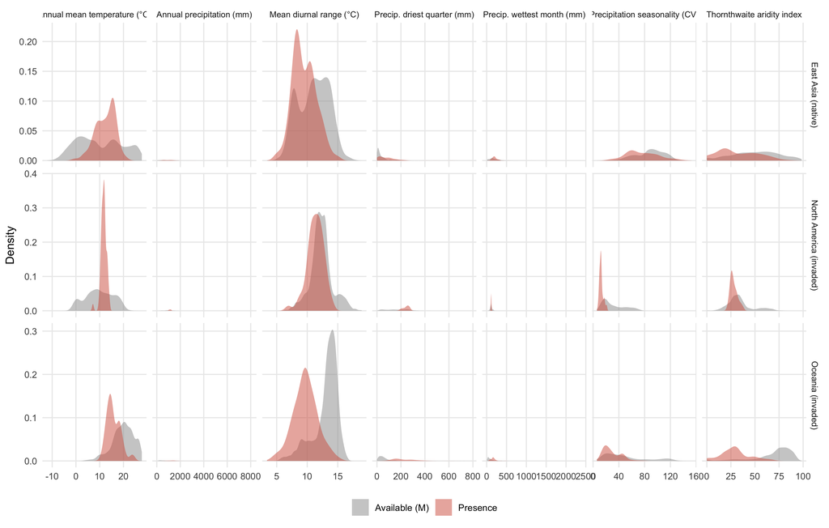

Figure S3: Distribution of the selected predictors at presence records and across the available environment (uniform background within *M*) for each calibration region.

```r
save_fig("FigS3_presence_vs_available", w = 11, h = 7)
```

```r
tune_all |> pivot_longer(c(loro_auc, loro_cbi, loro_or10, blk_auc, blk_cbi, blk_or10)) |>
  mutate(scheme = ifelse(grepl("loro", name), "Leave-one-region-out", "Spatial block"),
         metric = toupper(sub(".*_", "", name))) |>
  ggplot(aes(rm, value, colour = fc)) + geom_line() + geom_point(size = 1.5) +
  geom_point(data = \(d) semi_join(d, tune_sel, by = c("set", "fc", "rm")), shape = 21, size = 4, colour = "black") +
  facet_grid(metric ~ paste("Set", set) + scheme, scales = "free_y") +
  scale_colour_brewer(palette = "Dark2", name = "Features") +
  labs(x = "Regularisation multiplier (β)", y = NULL) + theme(strip.text = element_text(size = 7))
```

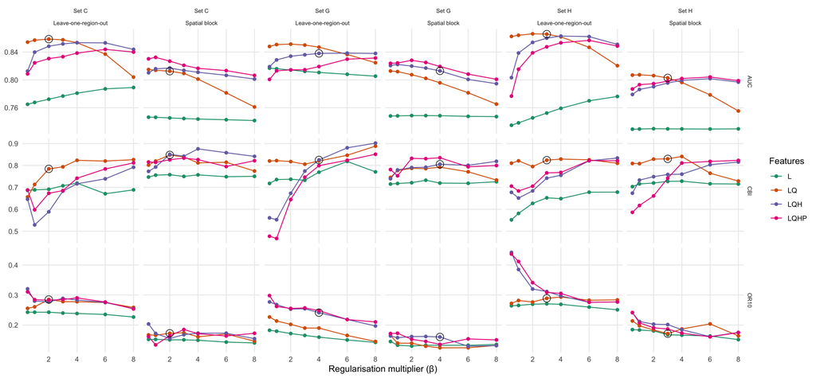

Figure S4: Cross-validated performance of MaxEnt configurations for each of the three predictor sets retained for the consensus. Circled points mark the configuration selected for each set.

```r
save_fig("FigS4_tuning", w = 14, h = 6.5)
```

```r
env_glob <- aggregate(crop(env_all[[sel_vars]], M_r), 4, mean, na.rm = TRUE) |> mask(aggregate(M_r, 4, max, na.rm = TRUE))
pred_glob <- ens_pred_rast(m_final, env_glob)
ggplot() + geom_sf(data = world50, fill = "grey93", colour = "grey75", linewidth = 0.1) +
  geom_spatraster(data = pred_glob) +
  scale_fill_viridis_c(option = "magma", direction = -1, limits = c(0, 1), na.value = NA, name = "Suitability") +
  geom_point(data = occ, aes(lon, lat), size = 0.3, colour = "cyan3") +
  coord_sf(xlim = c(-180, 180), ylim = c(-55, 70), expand = FALSE) + labs(x = NULL, y = NULL)
```

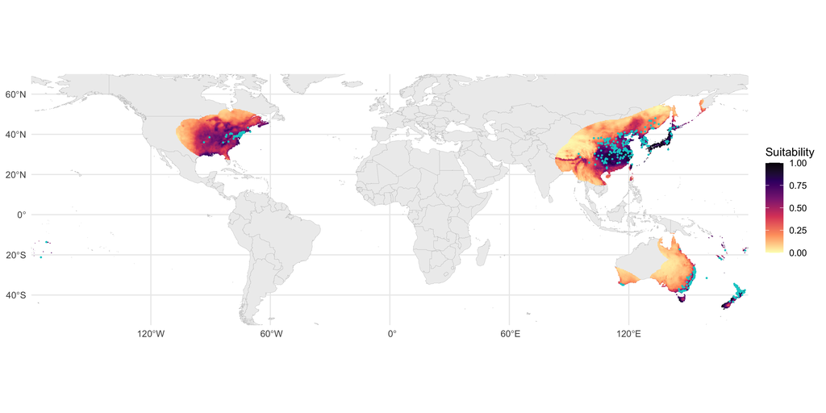

```r
save_fig("FigS5_global_suitability_M", w = 11, h = 5.5)
```

```r
mod_f <- as.factor(mod_r); lv <- levels(mod_f)[[1]]
levels(mod_f) <- data.frame(ID = lv[[1]], var = var_lab[sel_vars][lv[[1]]])
p_mess <- ggplot() + geom_spatraster(data = clamp(mess_r, -50, 50)) +
  scale_fill_gradient2(low = "#b2182b", mid = "white", high = "#2166ac", midpoint = 0, na.value = NA, name = "MESS") +
  map_base + labs(tag = "a")
p_mod <- ggplot() + geom_spatraster(data = mod_f) +
  scale_fill_brewer(palette = "Set2", na.value = NA, na.translate = FALSE, name = NULL) +
  geom_sf(data = aunz_sf, fill = NA, colour = "grey50", linewidth = 0.15) +
  map_base + labs(tag = "b") + theme(legend.position = "bottom")
p_mess + p_mod
```

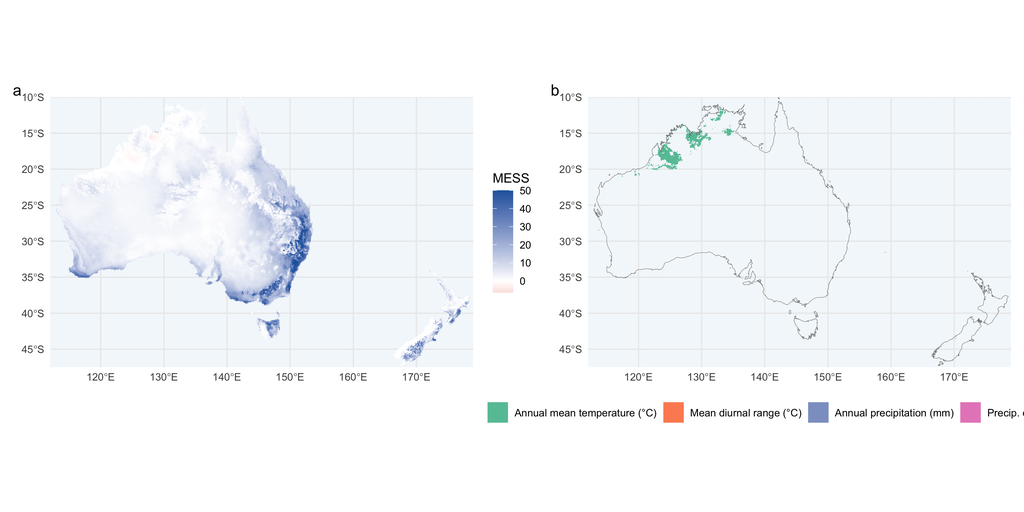

```r
save_fig("FigS6_mess_mod", p_mess + p_mod, 12, 6)
```

```r
p_sd <- ggplot() + geom_spatraster(data = boot_sd) +
  scale_fill_viridis_c(option = "viridis", na.value = NA, name = "SD") + map_base + labs(tag = "a")
p_ag <- ggplot() + geom_spatraster(data = boot_bin) +
  scale_fill_distiller(palette = "RdBu", direction = 1, limits = c(0, 1), na.value = NA, name = "Proportion of\nreplicates\nsuitable") +
  map_base + labs(tag = "b")
p_sd + p_ag
```

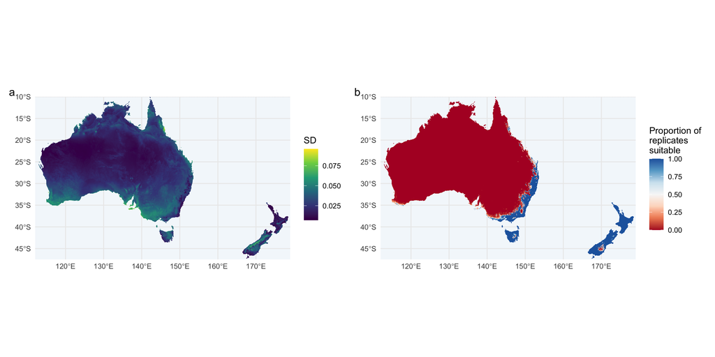

Figure S7: Bootstrap uncertainty (30 replicates). (a) Standard deviation of cloglog suitability. (b) Proportion of replicates classifying each cell as suitable at the final-model threshold.

```r
save_fig("FigS7_bootstrap_uncertainty", p_sd + p_ag, 12, 6)
```

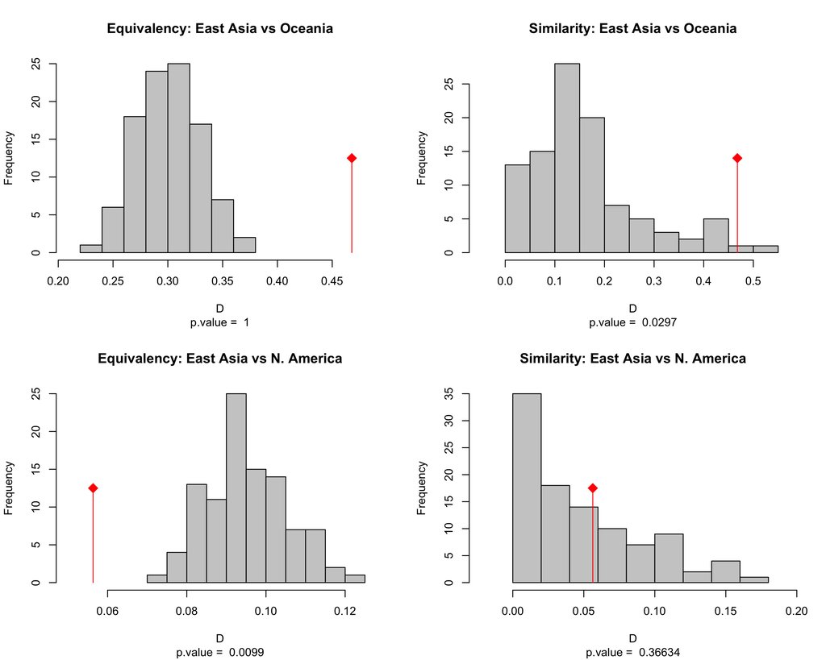

Figure S8: Null distributions of Schoener’s *D* from niche equivalency and similarity tests (100 randomisations); the red line shows observed overlap.

```r
par(mfrow = c(2, 2))
ecospat.plot.overlap.test(nc_oc$eq, "D", "Equivalency: East Asia vs Oceania")
ecospat.plot.overlap.test(nc_oc$sim, "D", "Similarity: East Asia vs Oceania")
ecospat.plot.overlap.test(nc_na$eq, "D", "Equivalency: East Asia vs N. America")
ecospat.plot.overlap.test(nc_na$sim, "D", "Similarity: East Asia vs N. America")
```

```r
p_u <- ggplot() + geom_spatraster(data = pred_unif) +
  scale_fill_viridis_c(option = "magma", direction = -1, limits = c(0, 1), na.value = NA, name = "Suitability") +
  map_base + labs(tag = "a")
sens_df <- as_tibble(sens_vals) |> setNames(c("bias", "unif")) |> slice_sample(n = 20000)
p_sc <- ggplot(sens_df, aes(bias, unif)) + geom_bin2d(bins = 60) + scale_fill_viridis_c(trans = "log10", name = "Cells") +
  geom_abline(linetype = 2) + labs(x = "Final model (bias-corrected background)", y = "Uniform background", tag = "b") +
  coord_equal()
p_u + p_sc
```

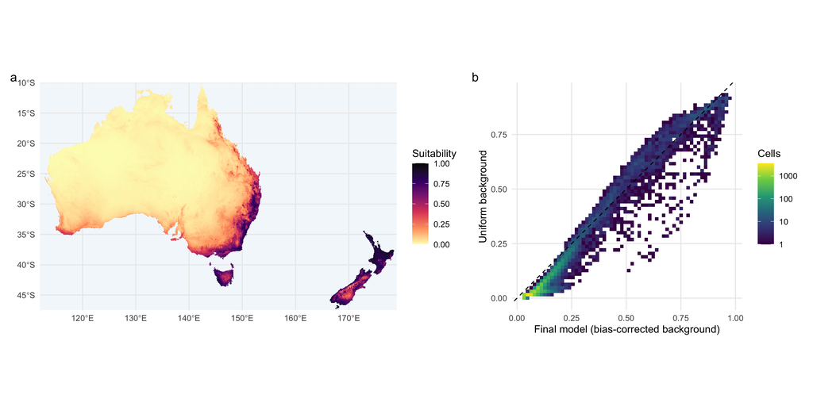

Figure S9: Sensitivity to background design. (a) Suitability predicted by the same configuration fitted with a uniform background. (b) Cell-wise comparison with the final model (Spearman ρ = 0.96; binary agreement = 98.8%). Cross-validated performance with the uniform background: LORO AUC = 0.87, LORO CBI = 0.83, block AUC = 0.82.

```r
save_fig("FigS8_background_sensitivity", p_u + p_sc, 12, 6)
```

## Computational environment

```r
key_results <- list(n_occ = n_occ, sel_sets = sel_sets, members = members, sel_vars = sel_vars, tune_sel = tune_sel,
                    n_feat = n_feat, cv = cvs_final, cv_folds = cv_final, insample = insample, thr_p10 = thr_p10,
                    thr_mss = thr_mss, tot = tot, area = area_tab, niche = niche_tab, var_imp = var_imp,
                    sens_cor = sens_cor, bin_agree = bin_agree, best_by_set = best_by_set)
saveRDS(key_results, file.path(out_dir, "key_results.rds"))
```